# Vignette: Intro to healthiar

This vignette introduces *healthiar* and shows how to use it with the help of examples. In addition, the descriptions of the [*healthiar* functions](https://swisstph.github.io/healthiar/reference/index.html) include short examples for every function, also for helper functions that this vignette only mentions (e.g. `get_risk()`, `get_paf()` or `discount()`). You can execute them (with *healthiar* loaded) by running `example("function_name")`, e.g. `example("get_risk")`.

Before using *healthiar*, please read the [README](https://github.com/SwissTPH/healthiar?tab=readme-ov-file#readme) or the [package website](https://swisstph.github.io/healthiar/). By using *healthiar*, you agree to its [disclaimer and license](https://github.com/SwissTPH/healthiar?tab=readme-ov-file#disclaimer-and-license).

# About *healthiar*

The *healthiar* functions allow you to quantify and monetize the health impacts (or burden of disease) attributable to exposure. The main focus of the EU project that initiated the development of *healthiar* (BEST-COST) has been two environmental exposures: air pollution and noise. However, *healthiar* could be used for other exposures such as green spaces, chemicals, physical activity…

See below an overview of *healthiar*, which is the first page of the [cheat sheet](https://swisstph.github.io/healthiar/articles/cheatsheet.html). The whole list of functions included in *healthiar* is linked there and available in the [reference](https://swisstph.github.io/healthiar/reference/index.html).

[figure not shown]

Figure: Overview of *healthiar*

# Input & output data

## Input

You can enter data in *healthiar* functions using:

- hard coded values or
- columns inside pre-loaded data frames or tibbles.

Let’s see some examples calling the most important function in *healthiar*: `attribute_health()`.

### Hard coded vs. columns

#### Hard coded

Depending on the function argument, you will need to enter numeric or character values.

```r
results_pm_copd <- attribute_health(
  exp_central = 8.85,
  rr_central = 1.369,
  rr_increment = 10,
  erf_shape = "log_linear",
  cutoff_central = 5,
  bhd_central = 30747
)
```

#### Columns

*healthiar* comes with some example data that start with `exdat_` that allow you to test functions. Some of these example data will be used in some examples in this vignette.

Now let’s call `attribute_health()` with input data from the *healthiar* example data. Note that you can easily provide input data to the function argument using the `$` operator.

```r
results_pm_copd <- attribute_health(
  erf_shape = "log_linear",
  rr_central = exdat_pm$relative_risk,
  rr_increment = 10,
  exp_central = exdat_pm$mean_concentration,
  cutoff_central = exdat_pm$cut_off_value,
  bhd_central = exdat_pm$incidence
)
```

### Tidy data

Be aware that *healthiar* functions are easier to use if your data is prepared in a tidy format, i.e.:

- Each variable is a column; each column is a variable.
- Each observation is a row; each row is an observation.
- Each value is a cell; each cell is a single value.

To know more about the concept of tidy format, see the article by (Wickham 2014).

For example, in `attribute_health()` the length of the input vectors to be entered in the arguments must be either 1 or the result of the combinations of the different values of:

- `geo_id_micro`
- `exp_...`
- `sex`
- `age`
- (`info` for further sub-group analysis)

## Output

#### Structure

The output of the *healthiar* functions `attribute_health()` and `attribute_lifetable()` consists of two lists (“folders”):

- `health_main` contains the main results
- `health_detailed` contains detailed results and additional info about the assessment.

In other *healthiar* functions you can find a similar output structure but using different prefixes. E.g., `social_` in `socialize()` and `monetization_` in `monetize()`.

#### Access

A similar structure can be found in other large functions in *healthiar*, e.g., `attribute_lifetable()`, `compare()`, `socialize()` or `monetize()`. In some functions, different elements are available in the output. For instance, `attribute_lifetable()` creates additional output that is specific to life table calculations.

There exist different, equivalent ways of accessing the output:

- With `$` operator: `results_pm_copd$health_main$impact_rounded` (as in the example above)
- By mouse: in the pane of your editor that lists the variables (e.g. *Environment* in RStudio), click on the variable you want to inspect, and then open the `health_main` results table
- By mouse: go to the *Environment* tab in RStudio and click on the variable you want to inspect, and then open the `health_main` results table
- With `[[]]` operator `results_pm_copd[["health_main"]]`
- With `pluck()` & `pull()`: use the `purrr::pluck` function to select a list and then the `dplyr::pull` function extract values from a specified column, e.g. `results_pm_copd |> purrr::pluck("health_main") |> dplyr::pull("impact_rounded")`

# Relative risk

### Goal

To quantify the health impacts attributable to an exposure using a relative risk and baseline health data.

### Methods

The comparative risk assessment approach (C. J. Murray et al. 2003) is applied obtaining the population attributable fraction (percent of cases that are attributable to the exposure) based on the relative risk. The exposure scenario is compared with a counterfactual scenario.

This approach has been extensively documented and applied (e.g., WHO 2003; Steenland and Armstrong 2006; Soares et al. 2022; Pozzer et al. 2023; GBD 2019 Risk Factors Collaborators 2020; Lehtomäki et al. 2025).

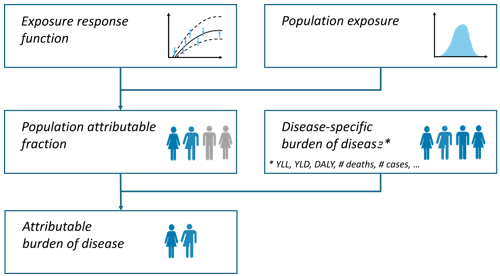

Figure: Relative risk approach

#### Population attributable fraction

General integral form for the population attributable fraction (PAF):

$$PAF = \frac{\int rr\_at\_exp(x) \times
prop\_pop\_exp(x)dx - 1}{\int rr\_at\_exp(x) \times
prop\_pop\_exp(x)dx}$$

Where:

- $x$ = exposure level
- $prop\_pop\_exp(x)$ = proportion of the population exposed at exposure level $x$
- $rr\_at\_exp(x)$ = relative risk at exposure level compared to the reference level

##### Simplified for categorical exposure distribution

If exposure is categorical, the integrals are converted to sums:

$$PAF = \frac{\sum rr\_at\_exp_i \times
prop\_pop\_exp_i - 1}{\sum rr\_at\_exp_i \times
prop\_pop\_exp_i}$$

Alternatively, an equivalent form is:

$$PAF = \frac{\sum prop\_pop\_exp_i \times
(rr\_at\_exp_i - 1)}{\sum prop\_pop\_exp_i\times (rr\_at\_exp_i - 1) +
1}$$

*healthiar* uses this second form, which is the one published as Formula 3 in ETC HE Report 2023/11. Note that $prop\_pop\_exp_i$ is the proportion of the *total* population in the exposure category $i$, so the $prop\_pop\_exp_i$ do *not* have to add up to 1: the part of the population that they do not cover is treated as unexposed, i.e. it gets the relative risk of the reference level. In air pollution assessments everybody is usually exposed and the $prop\_pop\_exp_i$ add up to 1, whereas in noise assessments they typically add up to less than 1, because exposure is only reported above a given level. Accordingly, the baseline health data entered in `bhd_...` must always refer to the total population. The first form above divides by $\sum rr\_at\_exp_i \times prop\_pop\_exp_i$ instead and is therefore only equivalent when $\sum prop\_pop\_exp_i = 1$.

##### Simplified for single exposure value

If there is one single exposure value, corresponding to the population weighted mean concentration, the equation can be simplified as follows:

- linear (Lehtomäki et al. 2025)
  $$RRexp = 1 + \frac{rr - 1}{increment} \times
  (exp - cutoff)$$
- log-linear (Lehtomäki et al. 2025)
  $$RRexp = e^{\frac{\log(rr)}{increment}
  \times (exp - cutoff)}$$
- log-log (Lehtomäki et al. 2025)
  $$RRexp = \left( \frac{exp + 1}{cutoff + 1}
  \right)^{\frac{\log(rr)}{\log(increment + cutoff + 1) - \log(cutoff +
  1)}}$$
- linear-log (Pozzer et al. 2023)
  $$RRexp = 1 + \frac{rr - 1}{\log(increment +
  cutoff + 1) - \log(cutoff + 1)} \times \log\left( \frac{exp + 1}{cutoff
  + 1} \right)$$

The relative risk at exposure level (`rr_at_exp`) is part of the output of `attribute_health()` and `attribute_lifetable()`. `rr_at_exp` can also be calculated using `get_risk()`.

For conversion of hazard ratios and/or odds ratios to relative risks refer to (VanderWeele 2019) and/or use the conversion tools developed by the Teaching group in EBM in 2022 for hazard ratios (https://ebm-helper.cn/en/Conv/HR_RR.html) and/or odds ratios (https://ebm-helper.cn/en/Conv/OR_RR.html).

### Example

In the example below, we quantify the COPD cases attributable to PM2.5 exposure in a country, using the example data `exdat_pm`.

#### Function call

```r
results_pm_copd <- attribute_health(
  approach_risk = "relative_risk", # If you do not call this argument, "relative_risk" will be assigned by default.
  erf_shape = "log_linear",
  rr_central = exdat_pm$relative_risk,
  rr_increment = 10,
  exp_central = exdat_pm$mean_concentration,
  cutoff_central = exdat_pm$cut_off_value,
  bhd_central = exdat_pm$incidence
)
```

#### Main results

```r
results_pm_copd$health_main
```

```
#> # A tibble: 1 × 24
#>   geo_id_micro erf_ci  exp_ci  bhd_ci  cutoff_ci exp_category sex   age_group
#>   <chr>        <chr>   <chr>   <chr>   <chr>            <int> <chr> <chr>
#> 1 a            central central central central              1 all   all
#> # ℹ 16 more variables: impact <dbl>, impact_rounded <dbl>, approach_risk <chr>,
#> #   rr_increment <dbl>, erf_shape <chr>, prop_pop_exp <dbl>, exp_length <int>,
#> #   exp_type <chr>, exp <dbl>, bhd <dbl>, cutoff <dbl>, rr <dbl>,
#> #   is_lifetable <lgl>, pop_fraction_type <chr>, rr_at_exp <dbl>,
#> #   pop_fraction <dbl>
```

Let’s zoom in on some relevant aspects.

```r
results_pm_copd$health_main |>
  dplyr::select(exp, bhd, rr, erf_ci, pop_fraction, impact_rounded) |>
  knitr::kable() # For formatting reasons only: prints tibble in nice layout
```

| exp | bhd | rr | erf_ci | pop_fraction | impact_rounded |
| --- | --- | --- | --- | --- | --- |
| 8.85 | 30747 | 1.369 | central | 0.1138961 | 3502 |

Interpretation: this table shows us that exposure was 8.85 $\mu g/m^3$, the baseline health data (`bhd_central`) was 30747 (COPD incidence in this instance). The 1st row further shows that the impact attributable to this exposure using the central relative risk (`rr_central`) estimate of 1.369 is 3502 COPD cases, or ~11% of all baseline cases.

Some of the most relevant results columns include:

- *impact_rounded* rounded attributable health impact/burden
- *impact* raw impact/burden
- *pop_fraction* population attributable fraction (PAF) or population impact fraction (PIF)

# Absolute risk

### Goal

To quantify the health impacts attributable to an exposure using an absolute risk, i.e. based on the exposed population instead of baseline health data.

### Methods

In the absolute risk calculation pathway, estimates are based on the size and distribution of the exposed population, rather than on baseline health data, as is the case in the relative risk pathway (WHO 2011).

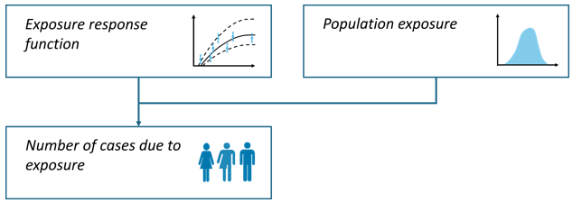

Figure: Absolute risk approach

$$impact = \sum
\frac{absolute\_risk\_as\_percent_i}{100} \times pop\_exp_i$$

Where:

- $impact$ = attributable cases
- $absolute\_risk\_as\_percent_i$ = absolute risk (in %) at exposure category $i$, obtained from the exposure-response function entered in `erf_eq_...`
- $pop\_exp_i$ = absolute population exposed at exposure category $i$
- $PE_i$ = absolute population exposed at category $i$

*healthiar* consistently handles cut-off values across both relative and absolute risk approaches. When a `cutoff_` argument is specified alongside an exposure–response function (`erf_eq_`), the function evaluates exposure as excess exposure relative to the cut-off (`c` as $\text{exp} - \text{cutoff}$), effectively shifting the function by the cut-off. However, many absolute risk curves published in the literature are parameterized on raw exposure levels that already incorporate the cut-off directly into the function definition. Therefore, *healthiar* issues an informative warning if both `erf_eq_` and a `cutoff_` are specified when using `attribute_health()`. If your absolute risk function is parameterized on raw exposure levels rather than on the exposure above the cut-off, see chapter Shifting the ERF.

### Example 1: several exposure categories

In the example below, we quantify the cases of high annoyance attributable to road traffic noise in five noise exposure bands.

#### Function call

```r
results_noise_ha <- attribute_health(
  approach_risk = "absolute_risk", # default is "relative_risk"
  exp_central = c(57.5, 62.5, 67.5, 72.5, 77.5), # mean of the exposure categories
  pop_exp = c(387500, 286000, 191800, 72200, 7700), # population exposed per exposure category
  erf_eq_central = "78.9270-3.1162*c+0.0342*c^2" # exposure-response function
)
```

The `erf_eq_central` argument can digest other types of functions (see section on user-defined ERF).

#### Main results

```r
results_noise_ha |>
  purrr::pluck("health_main") |>
  dplyr::select(erf_eq, erf_ci, impact_rounded) |>
  knitr::kable() # Prints tibble in a minimal layout
```

| erf_eq | erf_ci | impact_rounded |
| --- | --- | --- |
| 78.9270-3.1162*c+0.0342*c^2 | central | 174232 |

#### Results per noise exposure band

```r
results_noise_ha[["health_detailed"]][["results_raw"]] |>
  dplyr::select(exp_category, exp, pop_exp, impact) |>
  knitr::kable()
```

| exp_category | exp | pop_exp | impact |
| --- | --- | --- | --- |
| 1 | 57.5 | 387500 | 49674.594 |
| 2 | 62.5 | 286000 | 50788.595 |
| 3 | 67.5 | 191800 | 46813.105 |
| 4 | 72.5 | 72200 | 23657.232 |
| 5 | 77.5 | 7700 | 3298.314 |

### Example 2: one exposure category

Alternatively, it’s also possible to only assess the absolute risk impacts for one exposure category (e.g., a single noise exposure band).

#### Function call

```r
results_noise_ha <- attribute_health(
  approach_risk = "absolute_risk",
  exp_central = 57.5,
  pop_exp = 387500,
  erf_eq_central = "78.9270-3.1162*c+0.0342*c^2"
)
```

#### Main results

```r
results_noise_ha[["health_main"]] |>
  dplyr::select(exp_category, impact) |>
  knitr::kable()
```

| exp_category | impact |
| --- | --- |
| 1 | 49674.59 |

### Notes

**Important**: If the equation of the exposure-response function (`erf_eq_...`) requires taking a maximum in a vectorised context, `pmax()` must be used instead of `max()`. `pmax()` should be used whenever an element-wise maximum is required (the output will be a vector), while `max()` returns a single global maximum for the entire vector. For example:

```r
erf_eq_central <-
  "exp(0.2969*log((pmax(0,c-2.4)/1.9+1))/(1+exp(-(pmax(0,c-2.4)-12)/40.2)))"
```

In the following chapters, only the code to access the results is shown. The tables are formatted as above, i.e. selecting some columns with `dplyr::select()` and printing them with `knitr::kable()`.

# Multiple geographic units

## using relative risk

### Goal

To quantify health impacts using a relative risk in several geographic units with one single function call and, optionally, aggregate them into larger units.

### Example

In the example below, we quantify the disease cases attributable to PM2.5 exposure in five Swiss cantons and aggregate them by language region.

#### Function call

- Enter unique ID’s as a vector (`numeric` or `character`) to the `geo_id_micro` argument (e.g., municipality names or province abbreviations)
- Optional: aggregate unit-specific results by providing higher-level ID’s (e.g., region names or country abbreviations) as a vector (`numeric` or `character`) to the `geo_id_macro` argument

Input to the other function arguments is specified as usual, either as a vector or a single values (which will be recycled to match the length of the other input vectors).

```r
results_iteration <- attribute_health(
    # Names of Swiss cantons
    geo_id_micro = c("Zurich", "Basel", "Geneva", "Ticino", "Jura"),
    # Names of languages spoken in the selected Swiss cantons
    geo_id_macro = c("German","German","French","Italian","French"),
    rr_central = 1.369,
    rr_increment = 10,
    cutoff_central = 5,
    erf_shape = "log_linear",
    exp_central = c(11, 11, 10, 8, 7),
    bhd_central = c(4000, 2500, 3000, 1500, 500)
)
```

#### Main results

The main output contains aggregated results

```r
results_iteration$health_main
```

| geo_id_macro | impact_rounded | erf_ci | exp_ci | bhd_ci |
| --- | --- | --- | --- | --- |
| German | 1116 | central | central | central |
| French | 466 | central | central | central |
| Italian | 135 | central | central | central |

In this case `health_main` contains the number of disease cases attributable to PM2.5 exposure summed by language region. In total, the 5 cantons have 1717 attributable cases (using a relative risk of 1.369).

#### Detailed results

The geo unit-specific information and results are stored under `health_detailed`>`results_raw` .

```r
results_iteration$health_detailed$results_raw
```

| geo_id_micro | impact_rounded | geo_id_macro |
| --- | --- | --- |
| Zurich | 687 | German |
| Basel | 429 | German |
| Geneva | 436 | French |
| Ticino | 135 | Italian |
| Jura | 30 | French |

`health_detailed` also contains impacts obtained through all combinations of input data central, lower and upper estimates (as usual), besides the results per geo unit (not shown above).

## using absolute risk

### Goal

To quantify health impacts using an absolute risk in several geographic units with one single function call.

### Example

In the example below, we quantify the cases of high annoyance attributable to noise exposure in a rural and an urban area.

#### Function call

```r
data <- exdat_noise |>
  ## Filter for urban and rural regions
  dplyr::filter(region == "urban" | region == "rural")
```

```r
results_iteration_ar <- attribute_health(
    # Both the rural and urban areas belong to the higher-level "total" region
    geo_id_macro = "total",
    geo_id_micro = data$region,
    approach_risk = "absolute_risk",
    exp_central = data$exposure_mean,
    pop_exp = data$exposed,
    erf_eq_central = "78.9270-3.1162*c+0.0342*c^2"
)
```

**Important**: The length of the input vectors fed to `geo_id_micro`, `exp_central`, `pop_exp` must match and must be

(number of geo units) x (number of exposure categories) = 2 x 5 = 10,

because we have 2 geo units (`"rural"` and `"urban"`) and 5 exposure categories.

#### Main results

`health_main` contains the aggregated results (i.e. sum of impacts in rural and urban areas).

```r
results_iteration_ar$health_main
```

| geo_id_macro | impact_rounded | erf_ci | exp_ci |
| --- | --- | --- | --- |
| total | 174232 | central | central |

#### Detailed results

Impact by geo unit, in this case impact in the rural and in the urban area.

```r
results_iteration_ar$health_detailed$results_by_geo_id_micro
```

| geo_id_micro | geo_id_macro | impact |
| --- | --- | --- |
| urban | total | 150904.00 |
| rural | total | 23327.84 |

# Uncertainty

## Confidence interval

### Goal

To quantify health impacts taking into account the uncertainty (confidence intervals) of the input data.

### Example

In the example below, we quantify the COPD cases attributable to PM2.5 exposure with lower and upper bounds for the relative risk, the exposure and the baseline health data.

#### Function call

```r
results_pm_copd <- attribute_health(
    erf_shape = "log_linear",
    rr_central = 1.369,
    rr_lower = 1.124, # lower 95% confidence interval (CI) bound of RR
    rr_upper = 1.664, # upper 95% CI bound of RR
    rr_increment = 10,
    exp_central = 8.85,
    exp_lower = 8, # lower 95% CI bound of exposure
    exp_upper = 10, # upper 95% CI bound of exposure
    cutoff_central = 5,
    bhd_central = 30747,
    bhd_lower = 28000, # lower 95% confidence interval estimate of BHD
    bhd_upper = 32000 # upper 95% confidence interval estimate of BHD
)
```

#### Detailed results

Let’s inspect the detailed results:

```r
results_pm_copd$health_detailed$results_raw
```

| erf_ci | exp_ci | bhd_ci | impact_rounded |
| --- | --- | --- | --- |
| central | central | central | 3502 |
| lower | central | central | 1353 |
| upper | central | central | 5474 |
| central | central | lower | 3189 |
| lower | central | lower | 1232 |
| upper | central | lower | 4985 |
| central | central | upper | 3645 |
| lower | central | upper | 1408 |
| upper | central | upper | 5697 |

Each row contains the estimated attributable cases (`impact_rounded`) obtained by the input data specified in the columns ending in “_ci” and the other calculation pathway specifications in that row (not shown).

Only 9 of the 27 possible combinations and a selection of columns are shown.

If only some rows of your data have a confidence interval (e.g. one exposure-outcome pair has one, another has not), enter `NA` in the `_lower` and `_upper` values of the rows without it. Their lower and upper impacts are `NA`, and so are the sums that include them. `summarize_uncertainty()` requires values in all rows.

## Monte Carlo simulation

### Goal

To summarize the uncertainty of several input data into one single confidence interval of the attributable health impacts.

### Methods

#### General concepts

A Monte Carlo simulation is a statistical method that generates repeated random sampling (Robert and Casella 2004; Rubinstein and Kroese 2016). In *healthiar*, you can use the function `summarize_uncertainty()` to simulate values in the arguments with uncertainty and estimate a single confidence interval in the results.

For each entered input argument that includes a (95%) confidence interval (i.e. `_lower` and `_upper` bound value) a distribution is fitted (see distributions below). The median of the simulated attributable impacts is reported as the central estimate. The 2.5th and 97.5th percentiles of these simulated impacts define the lower and upper bounds of the 95% summary uncertainty interval. Aggregated estimates (e.g. for a `geo_id_macro` covering several `geo_id_micro`) are obtained by first summing the impacts of all lower level units within each simulation and only then taking the median and the 2.5th and 97.5th percentiles of these sums. Summing instead the central, lower and upper estimates of each lower level unit would assume that the uncertainty is perfectly correlated across the units and would therefore overestimate the width of the confidence interval.

#### Distributions used for simulation

`summarize_uncertainty()` assumes the following shapes of the distributions in the simulations:

- Relative risk: The values are simulated based on an optimized *gamma* distribution, which fits well as relative risks are positive and their distributions are usually right-skewed. The gamma distribution is parametrized such that its mean is equal to the central relative risk estimate (`rate= shape/rr_central`). The shape parameter is then optimized using `stats::optimize()` to match the inputed 95% confidence interval bounds, with `stats::qgamma()` used to evaluate candidate distributions. Finally, `n_sim` relative risk values are simulated using `stats::rgamma()`.
- Exposure, cutoff, baseline health data and duration: The values are simulated based on a *normal* distribution using `stats::rnorm()` with `mean = exp_central`, `mean = cutoff_central`, `mean = bhd_central` or `mean = duration_central` and a standard deviation based on corresponding lower and upper 95% exposure confidence interval values. The standard deviation is calculated as
  $$(upper-lower)/(2*1.96)$$
  , since for a normal distribution the 95% CI spans approximately two standard deviations on either side of the mean. As these four variables cannot be negative, the distribution is truncated at zero, i.e. negative values are discarded and drawn again until they are positive.
- Disability weights: The values are simulated based on a *beta* distribution, as both the disability weights and the beta distribution are bounded by 0 and 1. The beta distribution best fitting the inputted central disability weight estimate and corresponding lower and upper 95% confidence interval values is fitted using `stats::qbeta()` (the best fitting distribution parameters `shape1` and `shape2` are determined using `stats::optimize()`). For this purpose, we partly adapted the R function `prevalence::beta_expert` with permission of one of the authors (Devleesschauwer et al. 2022). Finally, `n_sim` disability weight values are simulated using `stats::rbeta()`.

For stability of the 95% confidence interval, a large number of simulations (e.g., 10,000) is recommended in practice. The example below uses n_sim = 100 for brevity.

### Example

In the example below, we summarize the uncertainty of the COPD cases from the chapter *Confidence interval*.

#### Function call

```r
results_pm_copd_summarized <-
  summarize_uncertainty(
    output_attribute = results_pm_copd,
    n_sim = 100
)
```

#### Main results

The outcome of the Monte Carlo analysis is added to the variable entered as the `output_attribute` argument, which is `results_pm_copd` in our case.

Two lists (“folders”) are added:

- `uncertainty_main` contains the central estimate and the corresponding 95% confidence intervals obtained through the Monte Carlo assessment and
- `uncertainty_detailed` contains all `n_sim` simulations of the Monte Carlo assessment.

```r
results_pm_copd_summarized$uncertainty_main
```

| geo_id_micro | impact_ci | impact | impact_rounded |
| --- | --- | --- | --- |
| a | central_estimate | 3530.588 | 3531 |
| a | lower_estimate | 1394.460 | 1394 |
| a | upper_estimate | 6027.056 | 6027 |

#### Detailed results

The folder `uncertainty_detailed` contains all single simulations. Let’s look at the impact of the first 10 simulations.

The columns `erf_ci`, `exp_ci`, `bhd_ci`, and `cutoff_ci` indicate the source of uncertainty component used for that simulation (in the first 10 simulations, all use central estimates).

```r
results_pm_copd_summarized$uncertainty_detailed$impact_by_sim
```

| geo_id_micro | erf_ci | exp_ci | bhd_ci | cutoff_ci | exp_category | sex | age_group | sim_id | impact | impact_rounded | approach_risk | rr_increment | erf_shape | prop_pop_exp | exp_length | exp_type | cutoff | is_lifetable | rr | exp | bhd | pop_fraction_type | rr_at_exp | pop_fraction |
| --- | --- | --- | --- | --- | --- | --- | --- | --- | --- | --- | --- | --- | --- | --- | --- | --- | --- | --- | --- | --- | --- | --- | --- | --- |
| a | central | central | central | central | 1 | all | all | 1 | 1935.156 | 1935 | relative_risk | 10 | log_linear | 1 | 1 | population_weighted_mean | 5 | FALSE | 1.251826 | 7.933793 | 30345.91 | paf | 1.068113 | 0.0637699 |
| a | central | central | central | central | 1 | all | all | 2 | 4698.352 | 4698 | relative_risk | 10 | log_linear | 1 | 1 | population_weighted_mean | 5 | FALSE | 1.430184 | 9.609612 | 30900.10 | paf | 1.179315 | 0.1520498 |
| a | central | central | central | central | 1 | all | all | 3 | 3722.356 | 3722 | relative_risk | 10 | log_linear | 1 | 1 | population_weighted_mean | 5 | FALSE | 1.414326 | 8.826146 | 29967.05 | paf | 1.141833 | 0.1242150 |
| a | central | central | central | central | 1 | all | all | 4 | 6061.313 | 6061 | relative_risk | 10 | log_linear | 1 | 1 | population_weighted_mean | 5 | FALSE | 1.570019 | 9.745453 | 31454.46 | paf | 1.238699 | 0.1927012 |
| a | central | central | central | central | 1 | all | all | 5 | 4045.348 | 4045 | relative_risk | 10 | log_linear | 1 | 1 | population_weighted_mean | 5 | FALSE | 1.479048 | 8.715480 | 29889.41 | paf | 1.156529 | 0.1353439 |
| a | central | central | central | central | 1 | all | all | 6 | 1756.592 | 1757 | relative_risk | 10 | log_linear | 1 | 1 | population_weighted_mean | 5 | FALSE | 1.143280 | 9.464298 | 30272.57 | paf | 1.061600 | 0.0580259 |
| a | central | central | central | central | 1 | all | all | 7 | 5447.089 | 5447 | relative_risk | 10 | log_linear | 1 | 1 | population_weighted_mean | 5 | FALSE | 1.728913 | 8.440255 | 31728.81 | paf | 1.207258 | 0.1716765 |
| a | central | central | central | central | 1 | all | all | 8 | 2354.822 | 2355 | relative_risk | 10 | log_linear | 1 | 1 | population_weighted_mean | 5 | FALSE | 1.202089 | 9.210268 | 31579.59 | paf | 1.080576 | 0.0745678 |
| a | central | central | central | central | 1 | all | all | 9 | 1699.985 | 1700 | relative_risk | 10 | log_linear | 1 | 1 | population_weighted_mean | 5 | FALSE | 1.169202 | 8.728108 | 30028.39 | paf | 1.060010 | 0.0566126 |
| a | central | central | central | central | 1 | all | all | 10 | 3659.699 | 3660 | relative_risk | 10 | log_linear | 1 | 1 | population_weighted_mean | 5 | FALSE | 1.345132 | 9.222098 | 31103.05 | paf | 1.133355 | 0.1176637 |

### Notes

**Important**: The normal distribution used for exposure, cutoff, baseline health data and duration is symmetric. Therefore, the simulated values reproduce the entered confidence interval only if the entered `_lower` and `_upper` values are symmetric around the `_central` value. Only the width of the entered confidence interval is used, not its shape. The more asymmetric the entered confidence interval, the more the simulated values will depart from it. Moreover, if the entered confidence interval is so wide that a relevant share of the distribution falls below zero, the truncation at zero shifts the simulated central estimate above the entered `_central` value.

# User-defined ERF

### Goal

To quantify health impacts with an exposure-response function of any shape, defined by the user instead of one of the predefined shapes.

### Example

In the example below, we quantify the COPD cases attributable to PM2.5 exposure with an exposure-response function defined by points, such as the MR-BRT curves of the Global Burden of Disease study.

#### Function call

In this case, the function arguments `erf_eq_...` require a function as input, so we use an auxiliary function (`splinefun()`) to transform the points on the ERF into type `function`.

```r
results_pm_copd_mr_brt <- attribute_health(
  exp_central = 8.85,
  bhd_central = 30747,
  cutoff_central = 0,
  # Specify the function based on x-y point pairs that lie on the ERF
  erf_eq_central = splinefun(
    x = c(0, 5, 10, 15, 20, 25, 30, 50, 70, 90, 110),
    y = c(1.00, 1.04, 1.08, 1.12, 1.16, 1.20, 1.23, 1.35, 1.45, 1.53, 1.60),
    method = "natural")
)
```

The ERF curve created looks as follows

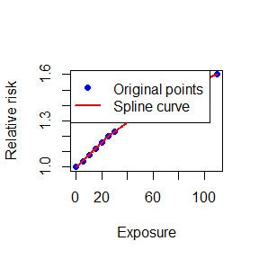

Alternatively, other functions (e.g. `approxfun()`) can be used to create the ERF

# Sub-group analysis

Every sub-group stratifies the assessment: by age group, by sex, or by anything entered in `info`, such as education level. What differs is what happens to that stratification in the main results.

For the sub-groups in this chapter the impacts are *summed*, so the stratification disappears from `health_main` and only the total per geographic unit is shown. It is still available in the `results_by_...` tables of the detailed output, and that is usually what you want: the total across education levels, or across age groups, is a meaningful number.

Not every dimension of an assessment is a sub-group in this sense, though. A stratification splits one population into parts that add up to the whole, which is exactly why summing them is meaningful. Different exposure-outcome pairs do not: PM2.5 and mortality and NO2 and asthma cover the *same* whole population, so they are parallel analyses rather than parts of one. Adding them up counts the same people twice.

Those dimensions therefore have to be *kept* in the main results, which is what the argument `main_results_by` does. See the chapter *Multiple exposure-outcome pairs*.

## by age group

### Goal

To quantify health impacts by age group.

### Example

In the example below, we quantify the health impacts attributable to air pollution in two age groups (below 65 and 65+).

#### Function call

To obtain age-group-specific results, the baseline health data (and possibly exposure) must be available by age group.

If the `age` argument was specified, age-group-specific results are available under `health_detailed` in the sub-folder `results_by_age_group`.

```r
results_age_group <- attribute_health(
        approach_risk = "relative_risk",
        age = c("below_65", "65_plus"),
        exp_central = c(8, 7),
        cutoff_central = c(5, 5),
        bhd_central = c(1000, 5000),
        rr_central = 1.06,
        rr_increment = 10,
        erf_shape = "log_linear"
      )
```

#### Results by age group

```r
results_age_group$health_detailed$results_by_age_group |>
  dplyr::select(age_group, impact_rounded, exp, bhd) |>
  knitr::kable()
```

| age_group | impact_rounded | exp | bhd |
| --- | --- | --- | --- |
| below_65 | 17 | 8 | 1000 |
| 65_plus | 58 | 7 | 5000 |

## by sex

### Goal

To quantify health impacts by sex.

### Example

In the example below, we quantify the health impacts attributable to air pollution in females and males.

#### Function call

The baseline health data (and possibly exposure) must be entered by sex.

```r
results_sex <- attribute_health(
        approach_risk = "relative_risk",
        sex = c("female", "male"),
        exp_central = c(8, 8),
        cutoff_central = c(5, 5),
        bhd_central = c(1000, 1100),
        rr_central = 1.06,
        rr_increment = 10,
        erf_shape = "log_linear"
      )
```

#### Results by sex

If the `sex` argument was specified, sex-specific results are available under `health_detailed` in the sub-folder `results_by_sex`.

```r
results_sex$health_detailed$results_by_sex |>
  dplyr::select(sex, impact_rounded, exp, bhd) |>
  knitr::kable()
```

| sex | impact_rounded | exp | bhd |
| --- | --- | --- | --- |
| female | 17 | 8 | 1000 |
| male | 19 | 8 | 1100 |

## by other sub-groups

### Goal

To quantify health impacts by any other sub-group, such as education level.

### Example

In the example below, we quantify the health impacts attributable to air pollution by education level in four geographic units.

#### Function call

A single vector (or a data frame / tibble with multiple columns) to group the results by can be entered to the `info` argument.

In a second step one can group the results based on one or more columns and so summarize the results by the preferred sub-groups.

If the argument `info` is a data frame or tibble, the columns in the `info` argument are renamed adding the prefix `info_`. If the argument `info` is a vector, the column in the results is called `info`.

```r
output_attribute <- healthiar::attribute_health(
    rr_central = 1.063,
    rr_increment = 10,
    erf_shape = "log_linear",
    cutoff_central =  0,
    exp_central = c(6, 7, 8,
                    7, 8, 9,
                    8, 9, 10,
                    9, 10, 11),
    bhd_central = c(600, 700, 800,
                    700, 800, 900,
                    800, 900, 1000,
                    900, 1000, 1100),
    geo_id_micro = rep(c("a", "b", "c", "d"), each = 3),
    info = data.frame(
      education = rep(c("secondary", "bachelor", "master"), times = 4)) # education level
  )
```

#### Results by other sub-group

```r
output_stratified <- output_attribute$health_detailed$results_raw |>
      dplyr::group_by(info_education) |>
      dplyr::summarize(mean_impact = mean(impact))|>
      dplyr::pull(mean_impact) |>
      print()
```

```
#> [1] 43.72087 54.26844 34.30332
```

## by age, sex and other sub-groups

### Goal

To quantify health impacts by several sub-groups at the same time, such as age, sex and education level.

### Example

In the example below, we quantify the health impacts attributable to air pollution by age group, sex and education level in two geographic units.

#### Function call

```r
output_attribute <- healthiar::attribute_health(
    rr_central = 1.063,
    rr_increment = 10,
    erf_shape = "log_linear",
    cutoff_central =  0,
    age_group = rep(c("50_and_younger", "50_plus"), each = 4, times= 2),
    sex = rep(c("female", "male"), each = 2, times = 4),
    exp_central = c(6, 7, 8, 7, 8, 9, 8, 9,
                    10, 9, 10, 11, 10, 11, 12, 13),
    bhd_central = c(600, 700, 800, 700, 800, 900, 800, 900,
                    1000, 900, 1000, 1100, 1000, 1100, 1200, 1000),
    geo_id_micro = rep(c("a", "b"), each = 8),
    info = data.frame(
      education = rep(c("without_master", "with_master"), times = 8)) # education level
  )
```

#### Results by all sub-groups

```r
output_stratified <- output_attribute$health_detailed$results_raw |>
      dplyr::group_by(info_education) |>
      dplyr::summarize(mean_impact = mean(impact))|>
      dplyr::pull(mean_impact) |>
      print()
```

```
#> [1] 52.80090 49.83826
```

# Multiple exposure-outcome pairs

### Goal

To quantify the health impacts of several exposure-outcome pairs, or of the same pair with different relative risks, in one single function call.

### Methods

As explained in the chapter *Sub-group analysis*, the impacts of the sub-groups are summed by default, so only the total per geographic unit is shown in `health_main`.

That is not what you want here. Premature deaths attributable to PM2.5 and asthma cases attributable to NO2 are not two parts of one population: they are two analyses of the *same* population, so adding them up counts the same people twice. The same applies to a sensitivity analysis in which one pair is quantified with the relative risks of two different studies: the two results are alternatives to each other, not summands.

Enter therefore in `main_results_by` the names of the dimensions that the main results have to be reported by. They stay as separate rows in `health_main` and in all `results_by_...` tables. Note that `main_results_by` does not create those tables, which are available in the detailed output in any case: it determines which dimensions survive in them and in the main results.

### Example 1: several exposure-outcome pairs

In the example below, we quantify the COPD cases attributable to PM2.5 and the asthma cases attributable to NO2 in two geographic units.

#### Function call

The pairs are identified in a column of `info`, and that column is named in `main_results_by`. All other arguments are entered as parallel vectors, exactly as for multiple geographic units. Note that the pairs can have different exposure-response functions, here log-linear for PM2.5 and linear for NO2.

```r
output_attribute <- healthiar::attribute_health(
    info = data.frame(
      pair = rep(c("pm2.5_copd", "no2_asthma"), each = 2)),
    main_results_by = "pair",
    exp_central    = c(8.85, 9.20, 22.1, 24.5),
    cutoff_central = c(5, 5, 10, 10),
    rr_central     = c(1.369, 1.369, 1.041, 1.041),
    rr_increment   = 10,
    erf_shape      = c("log_linear", "log_linear", "linear", "linear"),
    bhd_central    = c(30747, 31500, 12000, 12500),
    geo_id_micro   = rep(c("a", "b"), times = 2)
  )
```

#### Main results

One row per exposure-outcome pair and geographic unit. Without `main_results_by` the four impacts would have been added up into one single number per geographic unit.

```r
output_attribute$health_main |>
  dplyr::select(info_pair, geo_id_micro, erf_ci, impact_rounded) |>
  print()
```

```
#> # A tibble: 4 × 4
#>   info_pair  geo_id_micro erf_ci  impact_rounded
#>   <chr>      <chr>        <chr>            <dbl>
#> 1 pm2.5_copd a            central           3502
#> 2 pm2.5_copd b            central           3893
#> 3 no2_asthma a            central            567
#> 4 no2_asthma b            central            701
```

### Example 2: sensitivity analysis with several exposure-response functions

The same mechanism compares one exposure-outcome pair quantified with the relative risks of two different studies.

#### Function call

```r
output_sensitivity <- healthiar::attribute_health(
    info = data.frame(rr_source = c("Liu 2020", "WHO 2021")),
    main_results_by = "rr_source",
    exp_central = c(8.85, 8.85),
    cutoff_central = 5,
    rr_central = c(1.369, 1.080),
    rr_increment = 10,
    erf_shape = "log_linear",
    bhd_central = c(30747, 30747)
  )
```

#### Main results

```r
output_sensitivity$health_main |>
  dplyr::select(info_rr_source, erf_ci, impact_rounded) |>
  print()
```

```
#> # A tibble: 2 × 3
#>   info_rr_source erf_ci  impact_rounded
#>   <chr>          <chr>            <dbl>
#> 1 Liu 2020       central           3502
#> 2 WHO 2021       central            898
```

### Notes

#### Which dimensions can be entered

`main_results_by` is available in both `attribute_health()` and `attribute_lifetable()`. It accepts:

- the columns of `info`, using the names that you gave them (e.g. `"pair"`), or `"info"` itself if you entered a vector instead of a data frame;
- the arguments `sex`, `age_group`, `exp_category`, `geo_id_micro` and `geo_id_macro`;
- in `attribute_lifetable()` also `year`, i.e. the years of the time horizon, which are otherwise added up.

For example, `main_results_by = "sex"` shows one row per sex in `health_main` instead of the total across sexes. This changes nothing in the calculation, only which rows are kept apart in the results, and the rows still add up to the total that you would get without the argument.

A name that is not available in the assessment produces an error listing the options, so a typo in a column name of `info` cannot pass unnoticed.

#### Limitations

All pairs in one call must use the same way of defining the exposure-response function, i.e. either `rr_...` or `erf_eq_...` for all of them, and the same `approach_risk`.

`standardize()` keeps the pairs apart as well, so each pair gets its own age-standardized impacts. Nothing has to be done for that: its results simply carry the columns of `main_results_by`.

`socialize()` and `summarize_uncertainty()` analyse one pair at a time and stop with an error otherwise, so for them `attribute_health()` has to be called once per pair. The reason is different in each case. `socialize()` groups the impacts only by geographic unit, age group and social quantile, and its arguments have no way of identifying the pairs when the input is entered directly instead of as an `attribute_health()` output. `summarize_uncertainty()` simulates one value per variable and geographic unit, assuming that e.g. the relative risk is the same everywhere, which is not the case when each pair has its own.

# YLL & deaths with life table

The life table approach of `attribute_lifetable()` is only applicable to *all-cause mortality*. The baseline deaths (`bhd_central`) are used for two purposes at the same time: to project how the population survives over the years and to obtain the deaths that are attributable to the exposure. The projection of the population needs the deaths of all causes, so `bhd_central` must contain all-cause deaths and the exposure-response function must refer to all-cause mortality.

Cause-specific mortality (e.g. lung cancer) cannot be assessed with `attribute_lifetable()`:

- If only the cause-specific deaths are entered, the projected population hardly dies of any other cause and reaches unrealistically high ages. The YLL and the attributable deaths are then overestimated.
- If all-cause deaths are entered with a cause-specific exposure-response function, the relative risk is applied to all causes of death, which overestimates the impacts as well.

For cause-specific mortality, the attributable deaths can be obtained with `attribute_health()`.

## Data preparation

### Goal

To convert population and death data by larger age groups into the one-year age groups required by the life table approach.

### Methods

The life table approach to obtain YLL and deaths requires population and baseline mortality data to be stratified by *one year* age groups. However, in some cases these data are only available for larger age groups (e.g., 5-year data: 0-4 years old, 5-9 years old, …). What to do?

- If your population and mortality data are *not* available by one-year age group, data must be prepared by interpolating values. The *healthiar* function `prepare_lifetable()` makes this conversion using the same approach as the WHO tool AirQ+ (WHO 2020). In standard AirQ+ life table disaggregations, deaths are assumed to be distributed uniformly across age intervals with a fraction of the age interval lived of 0.5. The argument `fraction_lived` allows other assumptions, see the section on the fraction of the age interval lived below.
- If your population and death data are stratified by one-year age group, you are lucky, you can ignore this initial step. `prepare_lifetable()` passes single-year data on unchanged, so it can also be used for a life table that mixes already available single-year data with converted larger age groups.

#### Fraction of the age interval lived

The argument `fraction_lived`, available in both `prepare_lifetable()` and `attribute_lifetable()`, is the average fraction of an age interval that is lived by those who die in it. It corresponds to $_na_x$ in the life table literature (Chiang 1984; Preston et al. 2001). The default of 0.5 for all age groups means that deaths are evenly distributed over the age interval, which is the value that AirQ+ assumes (WHO 2020). It can be entered as a single value applying to all age groups or as one value per age group.

##### What it determines

With $_nm_x$ the death rate of an age interval of width $n$, the probability of dying in that interval is

$$_nq_x = \frac{n \times {}_nm_x}{1 + n
\times (1 - {}_na_x) \times {}_nm_x}$$

and the person-years lived at a single year of age, i.e. its mid-year population, is one year for each person reaching the next birthday plus $fraction\_lived$ years for each person dying at that age:

$$midyear\_population = entry\_population
- (1 - fraction\_lived) \times deaths$$

In `prepare_lifetable()` these two relations fix the conversion. The entry population of the first single year of age of an age group follows from the condition that the conversion may neither create nor lose population, i.e. that the single-year mid-year populations have to add up to the mid-year population of the age group that was entered:

$$entry\_population_{first} =
\frac{population + (1 - fraction\_lived) \times bhd}{\sum_{k = 0}^{n -
1} prob\_survival^{\,k}}$$

For $fraction\_lived = 0.5$ this reproduces the values published in the AirQ+ manual, and unlike the formula given there it holds for any age interval width and any value of `fraction_lived`.

Both relations are checked in internal tests in *healthiar* against a published life table, the abridged life table for Austrian males in 1992 (Preston et al. 2001), in which the fraction of the age interval lived ranges from 0.48 to 0.63 in the 5-year age groups and is 0.068 at age 0. Applying the probability of dying obtained by `prepare_lifetable()` to the published survivors reproduces the published deaths of that life table for every age group, and the entry population it determines from the published mid-year population and deaths at age 0 reproduces the published number of survivors.

##### What it does not determine

`fraction_lived` is *not* a way to control how the deaths of an age group are distributed over the single years of age it contains. That distribution follows from the survival probabilities, as in AirQ+, so `fraction_lived` influences it only indirectly and far too weakly to be used for it. Both quantities are distinct in the life table literature and the distribution of the deaths cannot be derived from $_na_x$ (Preston et al. 2001).

`prepare_lifetable()` can therefore not reproduce the concentration of deaths at age 0 that is observed in low-mortality settings. If the deaths at age 0 matter for your assessment, obtain single-year population and death data for the youngest ages instead of relying on the conversion.

##### How to choose it

The sensitivity of the survival probability to `fraction_lived` is

$$\frac{\partial \;
prob\_survival}{\partial \; fraction\_lived} = -
\frac{hazard\_rate^2}{(1 + (1 - fraction\_lived) \times
hazard\_rate)^2}$$

i.e. it grows with the square of the hazard rate. `fraction_lived` therefore matters little in the age groups with a low mortality and most in those with the highest mortality, which are the last ones. With the example data of this vignette, entering 0.1 for age 0 changes the YLL by 0.01%, whereas adapting the last age group changes them by 0.25%.

Values of $_na_x$ other than 0.5 are usually derived from the mortality level itself. For age 0 and for the ages 1 to 4, Preston et al. (2001) report rules of thumb going back to Coale and Demeny, e.g. $_1a_0 = 0.045 + 2.684 \times {}_1m_0$ for males with $_1m_0 < 0.107$. For an open-ended last age group, $_na_x$ is the remaining life expectancy $1 / {}_nm_x$, which can exceed the width of the age interval.

Whichever `fraction_lived` is used in `prepare_lifetable()` has to be passed on to `attribute_lifetable()`, which needs the same assumption to obtain the survival probabilities. The output column `fraction_lived_for_attribute` is provided for that purpose.

### Example

In the example below, we convert the population and deaths of four 5-year age groups into one-year age groups, once with the default and once with an age-specific fraction of the age interval lived.

#### Function call

```r
age_groups <- c(0, 5, 10, 15)
pop <- c(438200, 445100, 439800, 421500)
bhd_counts <- c(1420, 45, 50, 125)

# Standard uniform disaggregation (fraction_lived = 0.5)
prepared_data <- healthiar::prepare_lifetable(
  age_group = age_groups,
  population = pop,
  bhd = bhd_counts
  # fraction_lived = 0.5 (default)
)

# Age-group specific fraction of the age interval lived (first fraction_lived = 0.1)
prepared_data_with_age_specific_fraction_lived <- healthiar::prepare_lifetable(
  age_group = age_groups,
  population = pop,
  bhd = bhd_counts,
  fraction_lived = c(0.1, 0.5, 0.5, 0.5)
)
```

## YLL

### Goal

To quantify the years of life lost (YLL) attributable to an exposure using a life table.

### Methods

#### General concept

The life table methodology of `attribute_lifetable()` follows that of the WHO tool AirQ+ (WHO 2020), which is described in more detail by Miller and Hurley (2003). The generalized formulas, which do not assume a fixed fraction of life lived (fraction_lived = 0.5), are based on the foundational work by Chiang (1984). In short, two scenarios are compared:

First, the entry and mid-year populations of the (first) year of analysis in the unexposed scenario are determined using modified survival probabilities. Second, age-specific population projections using scenario-specific survival probabilities are done for both scenarios. Third, by subtracting the populations in the unexposed scenario from the populations in the exposed scenario the premature deaths/years of life lost attributable to the exposure are determined. An extensive life table case study is available in a report by Miller (2010).

Use the two arguments `approach_exposure` and `approach_newborns` to modify the life table calculation:

- `approach_exposure`
  - `"single_year"` (default): Population is exposed for only one year (year of analysis). Applicable for both deaths and YLL. The attributable deaths refer to the year of analysis only, while the YLL caused by the exposure in that year are accumulated across the year of analysis and the following years (see argument `time_horizon`).
  - `"constant"`: Population is exposed every year, i.e. air pollution exposure is sustained across the full projection horizon and attributable health impacts are projected and cumulated across the full lifetime period (see argument `time_horizon`). Applicable for both deaths and YLL.

  Both options give the same attributable deaths and YLL in the year of analysis, because they only differ from the following year on. By default, AirQ+ assumes that air pollution remains stable over time (WHO 2020): its results over several years (e.g. “YLL over 10 years”) correspond to `"constant"`, while the attributable deaths that it reports for the first year are the same with both options. A single-year exposure can only be obtained in AirQ+ with its advanced scenario “Change in pollution level” (WHO 2020), set to reduce the pollution level by 100% in the years after the year of analysis.
- `approach_newborns`
  - `"without_newborns"` (default): Population in the year of analysis is followed over time, without considering newborns being born.
  - `"with_newborns"`: For each year after the year of analysis n babies are born, with n being equal to the (male and female) population aged 0 that is provided in the argument population.

#### Last age group

The life table is closed at the last age group, i.e. the survivors of the last age group are not projected into a further age. This follows the usual practice in the life table method, which extends the life table up to an age past which the probability of survival is negligible and then sets the survival above it to zero (Miller and Hurley 2003).

The data must therefore reach an age at which survival is negligible, i.e. the last age group should be one in which essentially all remaining deaths occur. National life tables usually already close in this way, with a probability of dying of 1 in the last age group. If the last age group still has an appreciable number of survivors, those survivors are dropped from the projection: neither the life years they would still live, nor the difference in those life years between the exposed and the unexposed scenario, are counted. The attributable health impacts are then underestimated. With the example data used in this vignette, which end at age 99 and still have a survival probability of about 0.34 there, the underestimation is around 0.7%.

If that is the case, condense the last age group, i.e. sum the populations and the deaths of the highest ages into it, so that all remaining deaths fall within it. Do *not* add extra age groups beyond the data instead: the added ages would need a population greater than 0, that population would be considered exposed and would generate attributable health impacts of its own, and the results would then grow with the number of added age groups instead of converging.

#### Comparison with AirQ+

*healthiar* aligns with AirQ+ in the equations of the life table. The survival probability of AirQ+, $S_i = (2 - h_i) / (2 + h_i)$, is identical to the one used here with the default `fraction_lived = 0.5`, and the modified survival probability is obtained in both tools by dividing the hazard rate by the relative risk (which is equivalent to multiplying it by $1 - PAF$) (WHO 2020).

*healthiar* reproduces the results of AirQ+. For the same input data, the attributable YLL and premature deaths of both tools agree to the last decimal that AirQ+ prints, for an exposure of one single year as well as for a constant exposure, year by year and accumulated over several years, and so do the life expectancies with and without the exposure.

The comparison has to be made by sex, though, because the “All genders” results of AirQ+ are not the sum of its male and female results as in *healthiar*: AirQ+ obtains them from a life table in which the populations and the deaths of both sexes are pooled, which has to be entered and run separately (WHO 2020). With the data of the example below, the pooled life table for all genders in AirQ+ gives 1.6% more YLL than the sum of two sex-specific ones in *healthiar*. *healthiar* returns that pooled value too, when the populations and the deaths of both sexes are entered as one single life table, i.e. passing the same value in `sex` for every age group.

#### Determination of populations in the (first) year of analysis

##### Entry population

The entry (i.e. start of year) populations in both scenarios (exposed and unexposed) is determined as follows:

$$entry\_population_{year_1} =
midyear\_population_{year_1} + (1 - fraction\_lived) \times
deaths_{year_1}$$

##### Survival probabilities

###### Exposed scenario

The survival probabilities in the exposed scenario from start of year $i$ to start of year $i+1$ are calculated as follows:

$$prob\_survival =
\frac{midyear\_population_i - fraction\_lived \times
deaths_i}{midyear\_population_i + (1 - fraction\_lived) \times
deaths_i}$$

Analogously, the probability of survival from start of year $i$ to mid-year $i$:

$$prob\_survival\_until\_midyear = 1 - (1
- fraction\_lived) \times (1 - prob\_survival)$$

###### Unexposed scenario

The survival probabilities in the unexposed scenario are calculated as follows:

First, the age-group specific hazard rate in the exposed scenario is calculated using the inputted age-specific mid-year populations and deaths.

$$hazard\_rate =
\frac{deaths}{mid\_year\_population}$$

Second, the hazard rate is multiplied by the modification factor ($= 1 - PAF$) to obtain the age-specific hazard rate in the unexposed scenario.

$$hazard\_rate\_mod = hazard\_rate \times
modification\_factor$$

Third, the age-specific survival probabilities (from the start until the end in a given age group) in the unexposed scenario are calculated as follows:

$$prob\_survival\_mod = \frac{1 -
fraction\_lived \times hazard\_rate\_mod}{1 + (1 - fraction\_lived)
\times hazard\_rate\_mod}$$

##### Mid-year population

The mid-year population of the (first) year of analysis (year_1) in the unexposed scenario are determined as follows:

First, the survival probabilities from start of year $i$ to mid-year $i$ in the unexposed scenario is calculated as:

$$prob\_survival\_until\_midyear_{mod} = 1
- (1 - fraction\_lived) \times (1 - prob\_survival\_mod)$$

Second, the mid-year populations of the (first) year of analysis (year_1) in the unexposed scenario is calculated:

$$midyear\_population\_unexposed_{year_1}
= entry\_population_{year_1} \times
prob\_survival\_until\_midyear_{mod}$$

#### Population projection

Using the age group-specific and scenario-specific survival probabilities calculated above, future populations of each age-group under each scenario are calculated.

###### Exposed scenario

The population projections for the two possible options of `approach_exposure` (`"single_year"` and `"constant"`) for the exposed scenario are different. In the case of `"single_year"` exposure, the population projection for the years after the year of exposure uses the same (modified) survival probabilities as the unexposed scenario.

In the case of `"constant"` the population projection is done as follows:

First, the entry population of year $i+1$ is calculated (which is the same as the end of year population of year $i$) using the entry population of year $i$.

$$entry\_population_{i+1} =
entry\_population_i \times prob\_survival$$

Second, the mid-year population of year $i+1$ is calculated.

$$midyear\_population_{i+1} =
entry\_population_{i+1} \times
prob\_survival\_until\_midyear$$

###### Unexposed scenario

The entry and mid-year population projections in the unexposed scenario are done as follows:

First, the entry population of year $i+1$ is calculated (which is the same as the end of year population of year $i$) by multiplying the entry population of year $i$ and the modified survival probabilities.

$$entry\_population_{i+1} =
entry\_population_i \times prob\_survival\_mod$$

Second, the mid-year population of year $i+1$ is calculated.

$$midyear\_population_{i+1} =
entry\_population_{i+1} \times
prob\_survival\_until\_midyear_{mod}$$

### Example

In the example below, we quantify the YLL from all-cause mortality attributable to PM2.5 exposure, using the example life table `exdat_lifetable`.

#### Function call

```r
results_pm_yll <- attribute_lifetable(
  year_of_analysis = 2019,
  health_outcome = "yll",
  rr_central =  1.118,
  rr_increment = 10,
  erf_shape = "log_linear",
  exp_central = 8.85,
  cutoff_central = 5,
  min_age = 20, # age from which population is affected by the exposure
  # Life table information
  age_group = exdat_lifetable$age_group,
  sex = exdat_lifetable$sex,
  population = exdat_lifetable$midyear_population,
  # In the life table case, BHD refers to deaths
  bhd_central = exdat_lifetable$deaths
)
```

#### Main results

Total YLL attributable to exposure (sum of sex-specific impacts).

```r
results_pm_yll$health_main
```

| impact_rounded | erf_ci | exp_ci | bhd_ci |
| --- | --- | --- | --- |
| 28810 | central | central | central |

#### Detailed results

Attributable YLL results

- per year
- per age (group)
- per sex (if sex-specific life table data entered)

are available.

Below, the results per age and the population projections are shown for females; the results for males are also available.

##### YLL per year

Only a selection of years is shown.

```r
results_pm_yll$health_detailed$results_raw |>
  dplyr::summarize(
    .by = year,
    impact = sum(impact, na.rm = TRUE)
  )
```

| year | impact |
| --- | --- |
| 2019 | 1299.683 |
| 2020 | 2421.604 |
| 2021 | 2221.148 |
| 2022 | 2032.978 |
| 2023 | 1857.582 |
| 2024 | 1694.959 |
| 2025 | 1545.430 |
| 2026 | 1408.650 |
| 2027 | 1284.054 |
| 2028 | 1170.668 |

##### YLL per age

```r
results_pm_yll$health_detailed$intermediate_calculations |>
  dplyr::filter(sex == "female") |>
  dplyr::pull(impact_by_age_and_year) |>
  purrr::pluck(1)
```

| age_start | age_end | impact_2019 |
| --- | --- | --- |
| 91 | 92 | 29.480668 |
| 92 | 93 | 27.542091 |
| 93 | 94 | 25.166285 |
| 94 | 95 | 22.111703 |
| 95 | 96 | 18.514777 |
| 96 | 97 | 14.505077 |
| 97 | 98 | 11.222461 |
| 98 | 99 | 8.170093 |
| 99 | 100 | 31.772534 |

##### Population (exposed scenario)

The exposed scenario is the scenario with the exposure specified in the assessment.

```r
results_pm_yll$health_detailed$intermediate_calculations|>
  dplyr::filter(sex == "female") |>
  dplyr::pull(projection_if_exposed_by_age_and_year) |>
  purrr::pluck(1)
```

| age_start | midyear_population_2019 | midyear_population_2020 | midyear_population_2021 | midyear_population_2022 |
| --- | --- | --- | --- | --- |
| 91 | 10560 | 10980.4178 | 11536.8448 | 11815.045 |
| 92 | 8728 | 9105.4297 | 9498.3206 | 9979.643 |
| 93 | 7140 | 7377.6106 | 7725.1173 | 8058.449 |
| 94 | 5655 | 5910.7546 | 6133.2128 | 6422.105 |
| 95 | 4332 | 4582.9334 | 4813.1037 | 4994.250 |
| 96 | 3118 | 3436.4582 | 3654.9171 | 3838.479 |
| 97 | 2234 | 2419.2261 | 2682.1499 | 2852.657 |
| 98 | 1520 | 1695.7730 | 1848.4164 | 2049.304 |
| 99 | 2246 | 879.8714 | 988.6583 | 1077.651 |

##### Population (unexposed scenario)

The unexposed scenario is the scenario without exposure.

```r
results_pm_yll$health_detailed$intermediate_calculations|>
  dplyr::filter(sex == "female") |>
  dplyr::pull(projection_if_unexposed_by_age_and_year) |>
  purrr::pluck(1)
```

| age_start | midyear_population_2019 | midyear_population_2020 | midyear_population_2021 | midyear_population_2022 |
| --- | --- | --- | --- | --- |
| 91 | 10589.481 | 11037.9003 | 11589.268 | 11861.323 |
| 92 | 8755.542 | 9160.1507 | 9548.044 | 10024.990 |
| 93 | 7165.166 | 7428.2700 | 7771.543 | 8100.635 |
| 94 | 5677.112 | 5956.6019 | 6175.327 | 6460.700 |
| 95 | 4350.515 | 4622.8492 | 4850.437 | 5028.544 |
| 96 | 3132.505 | 3469.5619 | 3686.750 | 3868.253 |
| 97 | 2245.222 | 2444.9150 | 2707.987 | 2877.502 |
| 98 | 1528.170 | 1715.4685 | 1868.044 | 2069.045 |
| 99 | 2277.773 | 890.9436 | 1000.141 | 1089.095 |

## Deaths

### Goal

To quantify the premature deaths attributable to an exposure using a life table.

### Example

In the example below, we quantify the all-cause premature deaths attributable to PM2.5 exposure, using the same life table as for YLL.

#### Function call

See example on YLL for additional info on `attribute_lifetable()` calculations and its output.

```r
results_pm_deaths <- attribute_lifetable(
  health_outcome = "deaths",
  year_of_analysis = 2019,
  rr_central =  1.118,
  rr_increment = 10,
  erf_shape = "log_linear",
  exp_central = 8.85,
  cutoff_central = 5,
  min_age = 20, # age from which population is affected by the exposure
  # Life table information
  age_group = exdat_lifetable$age_group,
  sex = exdat_lifetable$sex,
  population = exdat_lifetable$midyear_population,
  bhd_central = exdat_lifetable$deaths
)
```

#### Main results

Total premature deaths attributable to exposure (sum of sex-specific impacts).

```r
results_pm_deaths$health_main$impact
```

[output not shown]

#### Detailed results

Attributable premature deaths results

- per year (if argument `approach_exposure = "constant"`)
- per age (group)
- per sex (if sex-specific life table data entered)

are available.

Below, the results for females are shown; the results for males are also available.

Because the function argument `approach_exposure` is not specified in this example, the default `approach_exposure = "single_year"` is used and the premature deaths refer to one year (the year of analysis). If you set `approach_exposure = "constant"`, results are projected and accumulated across the full time horizon.

```r
results_pm_deaths$health_detailed$intermediate_calculations|>
  dplyr::filter(sex == "female") |>
  dplyr::pull(projection_if_unexposed_by_age_and_year) |>
  purrr::pluck(1)
```

| yoa | age_group | age_start | age_end | bhd | deaths | population | fraction_lived | modification_factor | prob_survival | prob_survival_until_midyear | hazard_rate | is_exposed_age | prob_survival_mod | prob_survival_until_midyear_mod | hazard_rate_mod | midyear_population_yoa | entry_population_yoa | end_population_yoa | deaths_yoa | entry_population_yoa_plus_1 |
| --- | --- | --- | --- | --- | --- | --- | --- | --- | --- | --- | --- | --- | --- | --- | --- | --- | --- | --- | --- | --- |
| 2019 | 91 | 91 | 92 | 1498 | 1498 | 10560 | 0.5 | 0.9579656 | 0.8675391 | 0.9337696 | 0.1418561 | TRUE | 0.8727528 | 0.9363764 | 0.1358932 | 10589.481 | 11309.0 | 9869.961 | 1439.0387 | 11787.888 |
| 2019 | 92 | 92 | 93 | 1412 | 1412 | 8728 | 0.5 | 0.9579656 | 0.8503286 | 0.9251643 | 0.1617782 | TRUE | 0.8561675 | 0.9280837 | 0.1549779 | 8755.542 | 9434.0 | 8077.084 | 1356.9158 | 9869.961 |
| 2019 | 93 | 93 | 94 | 1302 | 1302 | 7140 | 0.5 | 0.9579656 | 0.8328841 | 0.9164420 | 0.1823529 | TRUE | 0.8393444 | 0.9196722 | 0.1746878 | 7165.166 | 7791.0 | 6539.333 | 1251.6674 | 8077.084 |
| 2019 | 94 | 94 | 95 | 1155 | 1155 | 5655 | 0.5 | 0.9579656 | 0.8146811 | 0.9073406 | 0.2042440 | TRUE | 0.8217767 | 0.9108884 | 0.1956588 | 5677.112 | 6232.5 | 5121.723 | 1110.7766 | 6539.333 |
| 2019 | 95 | 95 | 96 | 976 | 976 | 4332 | 0.5 | 0.9579656 | 0.7975104 | 0.8987552 | 0.2253001 | TRUE | 0.8051929 | 0.9025964 | 0.2158297 | 4350.515 | 4820.0 | 3881.030 | 938.9704 | 5121.723 |
| 2019 | 96 | 96 | 97 | 772 | 772 | 3118 | 0.5 | 0.9579656 | 0.7796804 | 0.8898402 | 0.2475946 | TRUE | 0.7879595 | 0.8939798 | 0.2371871 | 3132.505 | 3504.0 | 2761.010 | 742.9898 | 3881.030 |
| 2019 | 97 | 97 | 98 | 603 | 603 | 2234 | 0.5 | 0.9579656 | 0.7621771 | 0.8810885 | 0.2699194 | TRUE | 0.7710294 | 0.8855147 | 0.2585735 | 2245.222 | 2535.5 | 1954.945 | 580.5551 | 2761.010 |
| 2019 | 98 | 98 | 99 | 443 | 443 | 1520 | 0.5 | 0.9579656 | 0.7456216 | 0.8728108 | 0.2914474 | TRUE | 0.7550044 | 0.8775022 | 0.2791965 | 1528.170 | 1741.5 | 1314.840 | 426.6598 | 1954.945 |
| 2019 | 99 | 99 | 100 | 2231 | 2231 | 2246 | 0.5 | 0.9579656 | 0.3363082 | 0.6681541 | 0.9933215 | TRUE | 0.3552120 | 0.6776060 | 0.9515678 | 2277.773 | 3361.5 | 1194.045 | 2167.4549 | 1314.840 |

# YLD

### Goal

To quantify the years lived with disability (YLD) attributable to an exposure.

### Methods

To quantify the YLDs, you can use a prevalence-based or an incidence-based approach (Kim et al. 2022).

- Prevalence-based: Enter `1` (year) in the argument(s) `duration_...` and *prevalence* cases in `bhd_...`.
- Incidence-based: Enter the duration of the disease in years (value above 1) in `duration_...` and *incidence* cases in `bhd_...`.

In both approaches, enter the disability weight (between 0 and 1) in `dw_...`.

`duration_central` has no default value on purpose: if you enter `dw_central`, you must also enter `duration_central` and thereby choose one of the two approaches.

### Example

In the example below, we quantify the YLD attributable to PM2.5 exposure for a disease with 1,000 incidence cases, a duration of 10 years and a disability weight of 0.2.

#### Function call

```r
results_pm_copd_yld  <- attribute_health(
  rr_central = 1.1,
  rr_increment = 10,
  erf_shape = "log_linear",
  exp_central = 8.85,
  cutoff_central = 5,
  bhd_central = 1000,
  duration_central = 10,
  dw_central = 0.2
)
```

#### Main results

```r
results_pm_copd_yld$health_main
```

| erf_ci | impact |
| --- | --- |
| central | 72.05868 |

# DALY

### Goal

To quantify the disability-adjusted life years (DALY) attributable to an exposure as the sum of YLL and YLD.

### Methods

To obtain the attributable DALY, its two components, i.e. years of life lost (YLL) and years lived with disability (YLD), must be summed (GBD 2019 Risk Factors Collaborators 2020).

$$DALY = YLL + YLD$$

### Example 1: DALY of one scenario

In the example below, we add up the YLL and the YLD from the previous chapters, using the function `daly()`.

#### Function call

```r
results_daly <- daly(
     output_attribute_yll = results_pm_yll,
     output_attribute_yld = results_pm_copd_yld
)
```

#### Main results

YLL, YLD & DALY

```r
results_daly$health_main |>
  dplyr::select(impact_yll_rounded, impact_yld_rounded, impact_rounded)
```

| impact_yll_rounded | impact_yld_rounded | impact_rounded |
| --- | --- | --- |
| 28810 | 72 | 28882 |

### Example 2: DALY difference between two scenarios

`daly()` also accepts the outputs of `compare()` (see chapter *Comparison of two health scenarios*). Compare first the YLL and the YLD of the two scenarios separately and then enter both comparisons in `daly()` to obtain the difference in DALY between the scenarios.

#### Function call

```r
results_daly_comparison <- daly(
  output_attribute_yll = comparison_yll, # compare() output with YLL
  output_attribute_yld = comparison_yld  # compare() output with YLD
)
```

# Modification of scenarios

### Goal

To create a new scenario that differs from an existing assessment only in some input data, without entering all input data again.

### Example

In the example below, we change the exposure of an existing assessment from 8.85 to 6 $\mu g/m^3$.

#### Function call

```r
scenario_A <- attribute_health(
    exp_central = 8.85,   # EXPOSURE 1
    cutoff_central = 5,
    bhd_central = 25000,
    approach_risk = "relative_risk",
    erf_shape = "log_linear",
    rr_central = 1.118,
    rr_increment = 10)
```

The function `attribute_mod()` can be used to modify one or multiple arguments of `attribute_health()` in an existing scenario, e.g. `scenario_A`.

```r
scenario_B <- attribute_mod(
  output_attribute = scenario_A,
  exp_central = 6
)
```

This is equivalent to building the whole scenario again (see below), but more time and code efficient.

```r
scenario_B <- attribute_health(
    exp_central = 6,     # EXPOSURE 2
    cutoff_central = 5,
    bhd_central = 25000,
    approach_risk = "relative_risk",
    erf_shape = "log_linear",
    rr_central = 1.118,
    rr_increment = 10)
```

# Comparison of two health scenarios

### Goal

To quantify the difference in health impacts between two scenarios, e.g. before and after an intervention.

### Methods

Two approaches can be used for the comparison of scenarios:

- Delta: Subtraction of health impact in scenario 1 minus in scenario 2 (i.e. two PAF) (WHO Regional Office for Europe 2014)
- Population impact fraction (PIF) (WHO 2003; C. J. L. Murray et al. 2003; Askari and Namayandeh 2020).
- Population impact fraction (PIF) (WHO 2003; C. J. L. Murray et al. 2003; Askari and Namayandeh 2020).

Note that the PIF comparison approach assumes same baseline health data for scenario 1 and 2 (e.g., comparison of two scenarios at the same time point), while the delta comparison approach, the difference between two scenarios is obtained by subtraction. Therefore, the delta approach is suited for comparison of scenarios in different time points.

#### Population Impact Fraction (PIF)

The Population Impact Fraction (PIF) is defined as the proportional change in disease or mortality when exposure to a risk factor is changed, for instance due to an intervention.

##### General Integral Form

The most general equation describing this mathematically is an integral form (WHO 2003; C. J. L. Murray et al. 2003):

$$PIF = \frac{\int rr\_at\_exp(x) \times
prop\_pop\_exp\_1(x)dx - \int rr\_at\_exp(x) \times
prop\_pop\_exp\_2(x)dx}{\int rr\_at\_exp(x) \times
prop\_pop\_exp\_1(x)dx}$$

Where:

- $x$ = exposure level
- $prop\_pop\_exp\_1(x)$ = proportion of the population exposed at exposure level $x$ in scenario 1
- $prop\_pop\_exp\_2(x)$ = proportion of the population exposed at exposure level $x$ in scenario 2 (alternative scenario)
- $rr\_at\_exp(x)$ = relative risk at exposure level compared to the reference level

##### Categorical Exposure Form

If the population exposure is described as a categorical rather than continuous exposure, the integrals may be converted to sums (WHO 2003; C. J. L. Murray et al. 2003):

$$PIF = \frac{\sum rr\_at\_exp_{i} \times
prop\_pop\_exp\_1_{i} - \sum rr\_at\_exp_{i} \times
prop\_pop\_exp\_2_{i}}{\sum rr\_at\_exp_{i} \times
prop\_pop\_exp\_1_{i}}$$

Where:

- $i$ = the exposure category (e.g., in bins of 1 $\mu g/m^3$ $PM_{2.5}$ or 5 dB noise exposure)
- $prop\_pop\_exp\_1_i$ = proportion of the population in exposure category $i$ in scenario 1
- $prop\_pop\_exp\_2_i$ = proportion of the population in exposure category $i$ in scenario 2 (alternative scenario)
- $rr\_at\_exp_i$ = relative risk for exposure category level $i$ compared to the reference level

##### Population weighted mean concentration form

Finally, if the exposure is provided as the population weighted mean concentration, the equation for the PIF is reduced to:

$$PIF = \frac{rr\_at\_exp\_1 -
rr\_at\_exp\_2}{rr\_at\_exp\_1}$$

Where:

- $rr\_at\_exp\_1$ = relative risk at the exposure level in scenario 1
- $rr\_at\_exp\_2$ = relative risk at the exposure level in scenario 2 (alternative scenario)

### Example

In the example below, we compare the health impacts of a PM2.5 exposure of 8.85 $\mu g/m^3$ with those of 6 $\mu g/m^3$.

#### Function call

1. Use `attribute_health()` to calculate burden of scenarios A & B.

```r
scenario_A <- attribute_health(
    exp_central = 8.85,   # EXPOSURE 1
    cutoff_central = 5,
    bhd_central = 25000,
    approach_risk = "relative_risk",
    erf_shape = "log_linear",
    rr_central = 1.118,
    rr_increment = 10)
```

```r
scenario_B <- attribute_mod(
  output_attribute = scenario_A,
  exp_central = 6
)
```

2. Use `compare()` to compare scenarios A & B.

```r
results_comparison <- healthiar::compare(
  approach_comparison = "delta", # or "pif" (population impact fraction)
  output_attribute_scen_1 = scenario_A,
  output_attribute_scen_2 = scenario_B
)
```

The default value for the argument `approach_comparison` is `"delta"`. The alternative is `"pif"` (population impact fraction). See the function documentation of `compare()` for more details.

#### Main results

```r
results_comparison$health_main
```

| impact | impact_rounded | impact_scen_1 | impact_scen_2 | bhd | exp_category | exp_length | exp_type | exp_scen_1 | exp_scen_2 |
| --- | --- | --- | --- | --- | --- | --- | --- | --- | --- |
| 773.5564 | 774 | 1050.86 | 277.304 | 25000 | 1 | 1 | population_weighted_mean | 8.85 | 6 |

#### Detailed results

The `compare()` results contain two additional outputs in addition to those we have already seen:

- `health_detailed`
  - `scen_1` contains results of scenario 1 (scenario A in our case)
  - `scen_2` contains results of scenario 2 (scenario B in our case)

### Notes

**Important**: If your aim is to quantify health impacts from a *policy intervention*, you should use the *same year of analysis* and therefore *same health baseline data* in both scenarios. The only variable that should change in the second scenario is the exposure (change as a result of the intervention).

### Goal

To quantify the total health impact attributable to two correlated exposures.

### Methods

A methodological report of the EU project BEST-COST (Strak et al. 2024) identified three approaches to add up attributable health impacts from correlated exposures:

- Additive approach (Steenland and Armstrong 2006):

$$PAF_{additive} = PAF_{exposure1} +
PAF_{exposure2}$$

- Multiplicative approach (Jerrett et al. 2013):

$$PAF_{multiplicative} = \frac{\sum
prop\_pop\_exp \times (rr\_at\_exp_{multiplicative} - 1)}{\sum
prop\_pop\_exp \times (rr\_at\_exp_{multiplicative}-1) + 1}$$

$$rr\_at\_exp_{multiplicative} =
rr\_at\_exp_{exposure1} * rr\_at\_exp_{exposure2}$$

- Combined approach (Steenland and Armstrong 2006):

$$PAF_{combined} = 1-[(1-PAF_{exposure1})
\times (1-PAF_{exposure2})]$$

**Important**: To apply any of these approaches, the relative risks for one exposure must be adjusted for the second exposure and vice versa.

### Example

In the example below, we combine the impacts of PM2.5 and NO2 with the multiplicative approach, using the function `multiexpose()`.

#### Function call

```r
results_pm <- attribute_health(
  erf_shape = "log_linear",
  rr_central = 1.369,
  rr_increment = 10,
  exp_central = 8.85,
  cutoff_central = 5,
  bhd_central = 30747
)

results_no2 <- attribute_mod(
  output_attribute = results_pm,
  exp_central = 10.9,
  rr_central = 1.031
)

results_multiplicative <- multiexpose(
  output_attribute_exp_1 = results_pm,
  output_attribute_exp_2 = results_no2,
  exp_name_1 = "pm2.5",
  exp_name_2 = "no2",
  approach_multiexposure = "multiplicative"
)
```

#### Main results

```r
results_multiplicative$health_main
```

| impact_rounded |
| --- |
| 3988 |

# Standardization

### Goal

To obtain age-standardized health impacts, which allow comparing populations with different age structures.

### Methods

Age standardization involves adjusting the observed rates of a particular outcome to a standard population with a specific age structure. This is a technique used to allow the comparison of populations with different age structures (GBD 2019 Demographics Collaborators 2020; Ahmad et al. 2001). In *healthiar*, the function `standardize()` applies the direct method, where the age-specific rates observed in a study population are applied to a standard (reference) population distribution.

The standardized health impact rate is computed as
$$impact\_per\_100k\_inhab_{std} = \sum_{i=1}^{k}
(impact\_per\_100k\_inhab_i \times ref\_prop\_pop_i)$$

where:

- $impact\_per\_100k\_inhab_{std}$ is the age-standardized health impact rate.
- $impact\_per\_100k\_inhab_i$ is the impact rate observed in age group $i$ (e.g., impact per 100,000 inhabitants).
- $ref\_prop\_pop_i$ is the proportion of the reference population in age group $i$ .
- $k$ is the number of age groups.

### Example

In the example below, we standardize the health impacts of two age groups (below and above 40) with a reference population split equally between them.

#### Function call

```r
output_attribute <- attribute_health(
  rr_central = 1.063,
  rr_increment = 10,
  erf_shape = "log_linear",
  cutoff_central =  0,
  age_group = c("below_40", "above_40"),
  exp_central = c(8.1, 10.9),
  bhd_central = c(1000, 4000),
  population = c(100000, 500000)
  )

results <- standardize(
  output_attribute = output_attribute,
  age_group = c("below_40", "above_40"),
  ref_prop_pop = c(0.5, 0.5)
  )
```

#### Main results

Age-standardized impact rate:

```r
print(results$health_main$impact_per_100k_inhab)
```

```
#> [1] 49.91113
```

Age group-specific impact rate:

```r
print(results$health_detailed$results_raw$impact_per_100k_inhab)
```

```
#> [1] 48.28250 51.53977
```

# Preparation of exposure data

### Goal

To obtain the population-weighted mean exposure of geographic units from gridded concentration data and population data.

### Methods

The *healthiar* function `prepare_exposure()` helps users that do not have the exposure data (needed for *healthiar* functions), but only spatial concentration and population data. The function calculates an average concentration value in each geographic unit, weighted with population at each location.

$$exp = \frac{\sum_{i=1}^{n} (C_i \times
population_i)}{\sum_{i=1}^{n} population_i}$$

where:

- $exp$ = population-weighted mean exposure for the geographic unit.
- $C_i$ = pollutant concentration in grid cell $i$.
- $population_i$ = population count in grid cell $i$.
- $n$ = total number of grid cells contained by the geographic unit.

In case population is entered as count by geographic sub-unit, the function calculates the mean concentration in each sub-unit and aggregates it to higher-level geographic units. If no population data is entered, the function calculates a simple spatial mean concentration as exposure value.

The output of `prepare_exposure()` can be entered in the arguments `exp_central`, `exp_lower` and/or `exp_upper` in *healthiar* functions such as `attribute_health()`.

### Example

In the example below, we obtain the population-weighted mean PM2.5 exposure of neighbourhoods in Brussels (Belgium), aggregated by region.

#### Function call

```r
# exdat_pwm_1 = Pollution grid data
exdat_pwm_1 <- terra::rast(system.file("extdata", "exdat_pwm_1.tif", package = "healthiar"))

# exdat_pwm_2 = Data with the geo units and population data. This is pre-loaded in healthiar.
# If your raw data are in .gpkg format, you can use e.g.  sf::st_read()

pwm <- healthiar::prepare_exposure(
  poll_grid = exdat_pwm_1, # Formal class SpatRaster,
  geo_units = exdat_pwm_2, # sf of the geographic sub-units
  population = sf::st_drop_geometry(exdat_pwm_2$population), # population per geographic sub-unit
  geo_id_macro = sf::st_drop_geometry(exdat_pwm_2$region)) # higher-level IDs to aggregate
```

#### Main results

Within the function output, the list `exposure_main` contains the population-weighted mean exposures for the (higher-level) geographic units in the column `exposure_mean` and the total population in each unit in column `population_total`.

```r
 knitr::kable(as.data.frame(pwm$exposure_main))
```

| geo_id_macro | exposure_mean | population_total |
| --- | --- | --- |
| Center | 11.47271 | 203105 |
| East | 11.10716 | 187907 |
| North | 11.48670 | 257573 |
| South | 11.09940 | 308860 |
| West | 11.38849 | 298802 |

# Cut-off vs. threshold

### Goal

To quantify health impacts when the exposure data only cover exposures above a level (cut-off) that is higher than the effect threshold of the exposure-response function.

### Methods

*healthiar* distinguishes two exposure levels:

- `threshold` is the effect threshold, i.e. the exposure level from which the exposure-response function starts to show an effect. It is the anchor of the curve and is therefore subtracted from the exposure. The term is used in this sense in health risk assessment guidance, e.g., for environmental noise (Engelmann et al. 2025). Because the risk is expressed relative to the threshold, the threshold is also the counterfactual exposure of the assessment, i.e. the exposure of the hypothetical scenario that the actual exposure is compared with (C. J. Murray et al. 2003).
- `cutoff_...` is the exposure level below which no health impacts are quantified. It determines which exposures are assessed, not the level that they are compared with. Usually, the cut-off is assumed to be the effect threshold, and then it is the counterfactual exposure as well. This is how the term is used in health risk assessment guidance, e.g., for air pollution (WHO 2025), where one single level plays both roles.

Accordingly, there are three possible combinations:

**a) Cut-off equal to the effect threshold**

This is the default situation. Since both threshold and cut-off are usually identical, *healthiar* assumes that the values are the same, if one of them is missing. Therefore, in that case, it is enough to enter only one value. The exposure-response function is anchored at that level, which is therefore subtracted from the exposure, and the exposures below it get the risk at the reference level:

$$rr_{at\_exp} = f(\max(exp, threshold) - threshold)$$

The same result is obtained by entering only `cutoff_...`, only `threshold`, or both with the same value.

**b) Cut-off higher than the effect threshold**

The exposure-response function is truncated at the cut-off. The exposures above the cut-off are assessed with the risk referring to the effect threshold, while the exposures below the cut-off get the risk at the reference level:

$$rr_{at\_exp} =
\begin{cases}
1, & exp < cutoff \\
f(exp - threshold), & exp \ge cutoff
\end{cases}$$

In the absolute risk approach, the exposures below the cut-off get an absolute risk of 0 instead of a relative risk of 1, i.e. in both approaches no health impacts are attributed to them.

This is the case, e.g., in noise assessments under the Environmental Noise Directive, in which exposure data are only reported above a given exposure level (cut-off) although the exposure-response functions show effects already at lower exposures (effect threshold). Be aware that this results in a step in the exposure-response function at the cut-off and that the people exposed between the effect threshold and the cut-off get no attributable health impacts (i.e. a conservative estimate).

**c) Cut-off lower than the effect threshold**

The cut-off has no effect on the results and *healthiar* shows a warning. The reason is that the exposure-response function is anchored at the effect threshold, so the exposures below the effect threshold already get the risk at the reference level. A cut-off below the effect threshold cannot remove any additional exposure and the results are the same as if only `threshold` had been entered.

### Example

In the example below (case b above), we quantify the health impacts in the noise exposure groups above 55 dB (cut-off) with an effect threshold of 45 dB.

#### Function call

```r
results_cutoff_above_threshold <- healthiar::attribute_health(
  approach_risk = "relative_risk",
  erf_shape = "log_linear",
  rr_central = 1.055,
  rr_increment = 10,
  prop_pop_exp = c(300000,200000,150000,120000,100000,70000,60000)/10000000,
  exp_central = c(47,52,57,62,67,72,77),
  # Effect threshold, i.e. the anchor of the exposure-response function
  threshold = 45,
  # Cut-off, i.e. the exposures below it are not quantified
  cutoff_central = 55,
  bhd_central = 50000)$health_main$impact_rounded
```

Alternatively, the same result can be obtained by entering a user-defined exposure-response function in `erf_eq_...` which already includes the case distinction. This is only needed if the shape of the curve above the cut-off is not covered by the `erf_shape` options. The function arguments `erf_eq_...` require a function as input. Instead of using a `splinefun()` this can also be fulfilled by using a ‘function(c)’ which is of type ‘function’.

```r
#setting up function parameters
threshold <- 45
RR <- 1.055
cutoff <- 55
rr_increment <- 10

# define categorical function, the ifelse condition enables the case distinction
erf_function <- function(c){
  output <- ifelse(c<cutoff, 1, exp((log(RR)/rr_increment)*(c-threshold)))
  return(output)
}
# attribute_health
results_catERF_different_cutoff <- healthiar::attribute_health(
  approach_risk = "relative_risk",
  erf_eq_central = erf_function,
  prop_pop_exp = c(300000,200000,150000,120000,100000,70000,60000)/10000000,
  exp_central = c(47,52,57,62,67,72,77),
  cutoff_central=0,
  bhd_central=50000)$health_main$impact_rounded
```

The categorical ERF curve created looks as follows. The step at the cut-off is clearly visible.

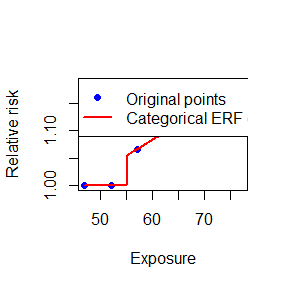

# Shifting the ERF

### Goal

To enter an exposure-response function in `erf_eq_...` correctly, depending on whether it already incorporates the cut-off.

### Methods

*healthiar* evaluates the exposure-response function entered in `erf_eq_...` at $c = exp - threshold$, and the threshold takes the value of the cut-off if it is not entered (see chapter Cut-off vs. threshold). The cut-off therefore moves the exposure-response function horizontally. There are two situations:

**a) Unshifted exposure-response function**

The function is parameterized on raw exposure levels, i.e. it already incorporates the cut-off in its definition. Do not enter a `cutoff_...` value, so that nothing is subtracted from the exposure, i.e. $c = exp$.

**b) Shifted exposure-response function**

The function is parameterized on the exposure above the cut-off, i.e. it does not incorporate the cut-off. Enter a value in the argument(s) `cutoff_...`, so that the function is moved horizontally by the cut-off, i.e. $c = exp - cutoff$.

In case b), *healthiar* shows a warning when a `cutoff_...` is entered alongside `approach_risk = "absolute_risk"`, because many exposure-response functions published in the literature already incorporate the cut-off in the function definition. The warning can be ignored here.

### Example

In the example below, the same absolute risk function is entered once unshifted and once shifted by a cut-off of 53 dB.

#### Function call

```r
# Case A: Unshifted exposure-response function
# The function is parameterized on raw exposure levels
unshifted_erf <- healthiar::attribute_health(
  approach_risk = "absolute_risk",
  exp_central = c(50, 60, 70),
  pop_exp = c(300000,200000,150000),
  erf_eq_central = "78.9270 - 3.1162 * c + 0.0342 * c^2"
)

# Case B: Shifted exposure-response function
# The function is parameterized on the exposure above the cut-off
shifted_erf <- healthiar::attribute_health(
  approach_risk = "absolute_risk",
  exp_central = c(50, 60, 70),
  pop_exp = c(300000,200000,150000),
  cutoff_central = 53,
  erf_eq_central = "78.9270 - 3.1162 * (c + 53) + 0.0342 * (c + 53)^2"
)
```

If you want the exposure-response function to stay unshifted but the exposures below a given level not to be quantified, enter a `cutoff_...` value higher than the `threshold` (see chapter Cut-off vs. threshold).

# Economic dimension

## Monetization

### Goal

To express attributable health impacts in monetary terms, optionally with discounting, inflation and growth in valuation.

### Methods

In health economic evaluations and economic burden of disease assessments, health impacts may need to be converted into monetary values. For this purpose, you can use `monetize()`.

Several valuation metrics are available, depending on how outcomes are quantified in natural or health units (e.g. cases reduced, deaths prevented, reductions in mortality risk, life-years gained, QALYs gained, DALYs averted). Common metrics include the Value of a Statistical Life (VSL) (OECD 2025), the Value of a Life-Year (VOLY) (Hammitt 2007) and the Value of a Quality-Adjusted Life-Year (VAQALY) (Bobinac et al. 2010).

Discounting is the practice of converting future costs (or health impacts as previous step to valuating them) into their present value. The underlying rationale is that the value placed on outcomes declines as they occur further in the future. Therefore, future costs and effects are converted into present-value terms to make them comparable over time (Attema et al. 2018).

Discounting is implemented by selecting a discount rate, which is used to compute a discount factor for each time period. This factor is then multiplied by the corresponding future cost (or effect) to express it in present-value terms.

If you need the discounted values of a cost or health outcome, you can call the *healthiar* function `discount()`. If you just need the discount factor, you can alternatively call `get_discount_factor()`. If you just need the inflation factor, you can call `get_inflation_factor()`, or the deflation factor by entering `is_deflation = TRUE` in the same function.

Different functional forms can be used to apply discounting. The most common is exponential discounting, also referred to as constant discounting, since outcomes are discounted proportionally as time increases. An alternative is hyperbolic discounting, which tends to better capture human behavior by discounting the near present more heavily than outcomes further in the future (Lipman and Attema 2024)

See below the equations that are used behind these functions.

In health economic evaluations and economic burden of disease assessments, health impacts may need to be converted into monetary values. For this purpose, you can use `monetize()`.

Several valuation metrics are available, depending on how outcomes are quantified in natural or health units (e.g. cases reduced, deaths prevented, reductions in mortality risk, life-years gained, QALYs gained, DALYs averted). Common metrics include the Value of a Statistical Life (VSL) (OECD 2025) , the Value of a Life-Year (VOLY) (Hammitt 2007) and the Value of a Quality-Adjusted Life-Year (VAQALY) (Bobinac et al. 2010).

Discounting is the practice of converting future costs (or health impacts as previous step to valuating them) into their present value. The underlying rationale is that the value placed on outcomes declines as they occur further in the future. Therefore, future costs and effects are converted into present-value terms to make them comparable over time (Attema et al. 2018).

Discounting is implemented by selecting a discount rate, which is used to compute a discount factor for each time period. This factor is then multiplied by the corresponding future cost (or effect) to express it in present-value terms.

Different functional forms can be used to apply discounting. The most common is exponential discounting, also referred to as constant discounting, since outcomes are discounted proportionally as time increases. An alternative is hyperbolic discounting, which tends to better capture human behavior by discounting the near present more heavily than outcomes further in the future (Lipman and Attema 2024)

See below the equations that are used behind these functions.

$$monetized\_impact = impact \times
valuation \times discount\_factor \times deflator\_factor \times
real\_growth\_factor$$
The arguments `discount_factor`, `deflator_factor` and `real_growth_factor` are only used if a value is entered in the arguments `discount_rate`, `inflation_rate` and `real_growth_rate` respectively
(otherwise ignored).

#### Discount factor

*Exponential discounting*

As suggested by Frederick et al. (2002)

$$discount\_factor = \frac{1}{(1 +
discount\_rate)^{n\_years}}$$

*Hyperbolic discounting Harvey*

As suggested by Harvey (1986)

$$discount\_factor = \frac{1}{(1 +
n\_years)^{discount\_rate}}$$

*Hyperbolic discounting Mazur*

As suggested by Mazur (1987)

$$discount\_factor = \frac{1}{1 +
(discount\_rate \times n\_years)}$$

#### Deflation factor

Inflation can be handled in `monetize()` by applying a deflator on future values, projected in nominal terms, in order to convert them into real values (i.e., express these values in terms of constant prices of a single base year). Therefore, if the user of the function provides a value for the `inflation_rate` argument, a deflator factor (HM Treasury 2022; Brealey et al. 2023; Samuelson 1937) is applied according to the following formulas

$$deflator\_factor = \frac{1}{(1 +
inflation\_rate)^{n\_years}}$$

The formula above assumes that inflation is constant over time. Because inflation usually varies from year to year, `inflation_rate` also accepts a vector of year-specific rates (at least as many values as years to be considered, the first value referring to the first year after the present). In that case, the deflator factor is calculated as the product of the year-specific factors

$$deflator\_factor =
\frac{1}{\prod_{t=1}^{n\_years}(1 + inflation\_rate_t)}$$

#### Real valuation growth

For this use case, you have to enter a value in the argument `real_growth_rate` in `monetize()`, which allows you to project this growth by applying a valuation growth factor to base-year unit values:

$$real\_growth\_factor =(1 +
real\_growth\_rate)^{n\_years}$$

Where $real\_growth\_rate$ represents the annual real growth rate in health valuation. As in `inflation_rate`, a vector of year-specific rates can be entered instead of one single value, in which case the factor is the product of the year-specific factors. This ensures that long-term environmental impacts are not undervalued.

The argument `output_attribute` accepts the output of `attribute_health()`, `attribute_lifetable()`, `compare()` or `daly()`. With the output of `attribute_lifetable()`, the impacts are monetized year by year and the number of years is taken from the life table. With the output of `daly()`, the YLL and the YLD are monetized separately and then summed, i.e. the YLL from the life table are discounted year by year, while `n_years` is used for the YLD.

### Example 1: output of `attribute_health()`

In the example below, we monetize the COPD cases from the chapter *Confidence interval* with a value of 50,000 EUR per case, discounted at 3% over 5 years.

#### Function call

```r
monetized_pm_copd <- monetize(
    output_attribute = results_pm_copd,
    discount_shape = "exponential",
    discount_rate = 0.03,
    n_years = 5,
    valuation = 50000 # E.g. EURO
)
```

#### Main results

The outcome of the monetization is added to the variable entered to the `output_attribute` argument, which is `results_pm_copd` in our case.

Two folders are added:

- `monetization_main` contains the central monetization estimate and the corresponding 95% confidence intervals obtained through the specified monetization.
- `monetization_detailed` contains the monetized results for each unique combination of the input variable estimates that were provided to the initial `attribute_health()` call.

```r
monetized_pm_copd$monetization_main
```

| erf_ci | monetized_impact |
| --- | --- |
| central | 151041153 |
| lower | 58358321 |
| upper | 236091201 |

We see that the central estimate of the monetized impact (discounted) is about 151 million EURO.

### Example 2: impacts from other sources

Alternatively, you can also monetize (attributable) health impacts from a non-*healthiar* source.

#### Function call

```r
results <- monetize(
  impact = 1151,
  valuation = 100
)
```

### Example 3: multiple exposure-outcome pairs

In the example below, we monetize the COPD cases attributable to PM2.5 and the asthma cases attributable to NO2 from the chapter *Multiple exposure-outcome pairs* in one single call, with a different value and discounting per pair.

The arguments describing the value of the health impact (`valuation`, `discount_rate` and `discount_shape`) are entered as vectors parallel to the arguments of `attribute_health()`, exactly as `exp_central` or `bhd_central`. They must have one single value per geographic unit and dimension entered in `main_results_by`, here per pair.

`real_growth_rate` can be entered in the same way (e.g. one rate per country, since it reflects income growth), constant over the years. A vector refers to year-specific rates only if `output_attribute` contains one single assessment.

In contrast, `inflation_rate` is the same for all pairs, so that all valuations share one price base: a vector entered there refers to year-specific rates.

#### Function call

```r
results_pairs <- attribute_health(
    info = data.frame(
      pair = rep(c("pm2.5_copd", "no2_asthma"), each = 2)),
    main_results_by = "pair",
    exp_central    = c(8.85, 9.20, 22.1, 24.5),
    cutoff_central = c(5, 5, 10, 10),
    rr_central     = c(1.369, 1.369, 1.041, 1.041),
    rr_increment   = 10,
    erf_shape      = c("log_linear", "log_linear", "linear", "linear"),
    bhd_central    = c(30747, 31500, 12000, 12500),
    geo_id_micro   = rep(c("a", "b"), times = 2)
  )

monetized_pairs <- monetize(
    output_attribute = results_pairs,
    valuation      = c(50000, 50000, 3000, 3000), # E.g. EURO per case
    discount_rate  = c(0.03, 0.03, 0.01, 0.01),
    discount_shape = rep(c("exponential", "hyperbolic_mazur_1987"), each = 2),
    n_years = 5
)
```

#### Main results

One row per exposure-outcome pair and geographic unit, each monetized with its own value and discounting.

```r
monetized_pairs$monetization_main |>
  dplyr::select(info_pair, geo_id_micro, valuation, discount_rate,
                discount_shape, monetized_impact_rounded) |>
  knitr::kable()
```

| info_pair | geo_id_micro | valuation | discount_rate | discount_shape | monetized_impact_rounded |
| --- | --- | --- | --- | --- | --- |
| pm2.5_copd | a | 50000 | 0.03 | exponential | 151041153 |
| pm2.5_copd | b | 50000 | 0.03 | exponential | 167901617 |
| no2_asthma | a | 3000 | 0.01 | hyperbolic_mazur_1987 | 1620520 |
| no2_asthma | b | 3000 | 0.01 | hyperbolic_mazur_1987 | 2004072 |

## Cost-benefit analysis

### Goal

To compare the monetized health benefits of an intervention with its costs.

### Methods

The CBA is a type of economic evaluation that compares the costs and the benefits of an intervention, considering both measures expressed in monetary terms.

To perform a CBA, you can use the function `cba()`. This approach requires monetizing benefits so they can be directly compared with costs. Since interventions typically generate costs and benefits over multi-year time horizons, discounting is a common practice to obtain the present value of future costs and benefits. Depending on the reference guidelines, the discount rate can be specified as the same for costs and benefits or different across them. The outputs of a Cost-Benefit Analysis can be expressed as three main indicators (Boardman et al. 2018):

- intervention’s net benefit: the difference between monetized benefits and costs
- Cost-Benefit Ratio (CBR): monetized benefits divided by costs and
- Return on Investment (ROI): return generated per unit of expenditure by relating net benefits to the intervention’s costs.

An intervention is recommended from a Cost-Benefit Analysis perspective, if it yields a positive net benefit or a positive ROI, or equivalently, a CBR greater than one, meaning that the intervention’s monetized benefits exceed its costs. These three outputs are available when running `cba()` and are calculated considering the following formulas.

**Net Benefit**
$$net\_benefit = benefit - cost$$

**Cost-Benefit Ratio (CBR)**
$$cbr = \frac{benefit}{cost}$$

**Return on Investment (ROI)**
$$roi = \frac{benefit - cost}{cost} \times
100$$

### Example

Let’s imagine we design a policy that would reduce air pollution to 5 $\mu g/m^3$, which is the concentration specified in the `cutoff_central` argument in the initial `attribute_health()` call. So we could avoid all COPD cases attributed to air pollution.

#### Function call

Considering the cost to implement the policy (estimated at 100 million EURO), what would be the monetary net benefit of such a policy? We can find out using the *healthiar* function `cba()`.

```r
cba <- cba(
    output_attribute = results_pm_copd,
    valuation = 50000,
    cost = 100000000,
    discount_shape = "exponential",
    discount_rate_benefit = 0.03,
    discount_rate_cost = 0.03,
    n_years_benefit = 5,
    n_years_cost = 5
)
```

#### Main results

The outcome of the CBA is contained in two folders, which are added to the existing assessment:

The outcome of the CBA is contained in two folders, which are added to the existing assessment:

- `cba_main` contains the central estimate and the corresponding 95% confidence intervals obtained
- `cba_detailed` contains additional intermediate results for both cost and benefit
  - `benefit` contains results `by_year` and raw results `health_raw`
  - `cost` contains the costs of the policy at the end of the period specified in the `n_years_cost` argument

```r
cba$cba_main |>
  dplyr::select(benefit, cost, net_benefit) |>
  knitr::kable()
```

| benefit | cost | net_benefit |
| --- | --- | --- |
| 151041153 | 86260878 | 64780274 |
| 58358321 | 86260878 | -27902557 |
| 236091201 | 86260878 | 149830323 |

We see that the central and upper 95% confidence interval estimates of avoided attributable COPD cases result in a net monetary benefit of the policy, while the lower 95% confidence interval estimate results in a net cost!

# Social aspects

## Health impact attributable to social indicator

### Goal

To quantify the differences in attributable health impacts between more and less deprived areas.

### Methods

Taking into account socio-economic indicators, e.g. a multiple deprivation index (Mogin et al. 2025), the differences in attributable health impacts across the study areas can be estimated (Renard et al. 2019; Otavova et al. 2022).

Social inequalities are quantified as the difference between the least deprived areas (the last n-quantile) and

- the most deprived areas or
- the population overall.

These differences can be

- absolute or
- relative.

Geographic units without a value in the social indicator (`NA`), e.g. because the deprivation index is not available for small areas, cannot be assigned to a quantile. They are left out of the comparison between the most and least deprived quantiles. However, they still count in the overall values, because the overall values refer to the whole study area, i.e. the health impacts that were estimated. If you prefer to exclude them from the overall values too, remove them before calling the attribute function.

#### Difference most deprived vs. least deprived

$$absolute\_quantile = first - last$$
Where:

- $absolute\_quantile$ = Absolute difference between quantiles.
- $first$ = Average health impacts in *most* deprived quantile.
- $last$ = Average health impacts in *least* deprived quantile.

$$relative\_quantile =
\frac{absolute\_quantile}{last}$$

#### Difference overall vs. least deprived

$$absolute\_overall = overall - last$$
Where:

- $absolute\_overall$ = Absolute difference regarding the overall average.
- $overall$ = *Overall* average health impacts in the study area.
- $last$ = Average health impacts in *least* deprived quantile.

If you assume that the least deprived areas are similar to counterfactual cases (no exposure to deprivation), the relative difference regarding the overall average health impact could be interpreted as some kind of relative risk attributable to social inequalities.

### Example

In the example below, we compare the mortality attributable to PM2.5 exposure across deciles of a deprivation score.

#### Function call

First, quantify health impacts.

```r
 health_impact <- healthiar::attribute_health(
   age_group = exdat_socialize$age_group,
   exp_central = exdat_socialize$pm25_mean,
   cutoff_central = 0,
   rr_central = exdat_socialize$rr,
   erf_shape = "log_linear",
   rr_increment = 10,
   bhd_central = exdat_socialize$mortality,
   population = exdat_socialize$population,
   geo_id_micro = exdat_socialize$geo_unit)
```

Second, use the function `socialize()` entering the whole output of `attribute_health()` in the argument `output_attribute`.

```r
social_t <- healthiar::socialize(
  output_attribute = health_impact,
  age_group = exdat_socialize$age_group, # They have to be the same in socialize() and in attribute_health()
  ref_prop_pop = exdat_socialize$ref_prop_pop, # Population already provided in output_attribute
  geo_id_micro = exdat_socialize$geo_unit,
  social_indicator = exdat_socialize$score,
  n_quantile = 10,
  increasing_deprivation = TRUE)
```

Alternatively, you can directly enter the health impact in the `socialize()` argument `impact`.

```r
social <- healthiar::socialize(
  impact = health_impact$health_detailed$results_by_age_group$impact,
  age_group = exdat_socialize$age_group, # They have to be the same in socialize() and in attribute_health()
  ref_prop_pop = exdat_socialize$ref_prop_pop,
  geo_id_micro = exdat_socialize$geo_unit,
  social_indicator = exdat_socialize$score,
  population = exdat_socialize$population, # Population has to be provided because no output_attribute
  n_quantile = 10,
  increasing_deprivation = TRUE)
```

#### Main results

```r
social$social_main |>
  dplyr::select(c(parameter, difference_type,
                  difference_compared_with, difference_value,
                  comment)) |>
  print()
```

```
#> # A tibble: 4 × 5
#>   parameter      difference_type difference_compared_…¹ difference_value comment
#>   <chr>          <chr>           <chr>                             <dbl> <chr>
#> 1 impact_rate_s… absolute        last_quantile                    26.5   <NA>
#> 2 impact_rate_s… relative        last_quantile                     0.597 <NA>
#> 3 impact_rate_s… absolute        overall                          14.2   It can…
#> 4 impact_rate_s… relative        overall                           0.242 It can…
#> # ℹ abbreviated name: ¹difference_compared_with
```

## Multiple deprivation index

### Goal

To create a multiple deprivation index (MDI) from several socio-economic indicators, e.g. to enter it in the argument `social_indicator` of `socialize()`.

### Methods

Socio-economic indicators (e.g., education level, employment status and family structure) can be condensed into a multiple deprivation index (MDI) (Mogin et al. 2025). For this purpose, the indicators can be normalized using min-max scaling.

The reliability of the MDI can be assessed using Cronbach’s alpha (Cronbach 1951).

$$\alpha = \frac{k}{k - 1} \left( 1 -
\frac{\sum_{i=1}^{k} \sigma^2_{y_i}}{\sigma^2_x} \right)$$
where:

- $k$ is the number of items/variables.
- $\sigma^2_{y_i}$ is the variance of the $i$-th item.
- $\sum_{i=1}^{k} \sigma^2_{y_i}$ is the sum of the variances of all items.
- $\sigma^2_x$ is the total variance of the observed total scores (the sum of all items).

To apply this approach, you should ensure that the data set is as complete as possible. Otherwise, you can try to impute missing data using:

- Time-Based Imputation: Linear regression based on historical trends if prior years’ data is complete.
- Indicator-Based Imputation: Multiple linear regression if the missing indicator correlates strongly with others.

To apply this approach, you should ensure that the data set is as complete as possible. Otherwise, you can try to impute missing data using: - Time-Based Imputation: Linear regression based on historical trends if prior years’ data is complete. - Indicator-Based Imputation: Multiple linear regression if the missing indicator correlates strongly with others.

Imputation models should have an R^2 greater than or equal to 0.7. If R^2 lower than 0.7, consider alternative data sources or methods.

### Example

In the example below, we create an MDI from five indicators (education, unemployment, single parents, population change and lack of heating) and split it into deciles.

#### Function call

```r
mdi <- prepare_mdi(
  geo_id_micro = exdat_prepare_mdi$id,
  edu = exdat_prepare_mdi$edu,
  unemployed = exdat_prepare_mdi$unemployed,
  single_parent = exdat_prepare_mdi$single_parent,
  pop_change = exdat_prepare_mdi$pop_change,
  no_heating = exdat_prepare_mdi$no_heating,
  n_quantile = 10,
  verbose = FALSE
)
```

`verbose = FALSE` suppresses any output to the console (default: `verbose = TRUE`, i.e. with printing turned on).

#### Main results

Function output includes:

- `mdi_main`, a tibble containing the BEST-COST MDI

```r
mdi$mdi_main |>
  dplyr::select(geo_id_micro, MDI, MDI_index)
```

| geo_id_micro | MDI | MDI_index |
| --- | --- | --- |
| 11001 | 0.2117721 | 1 |
| 11002 | 0.4319924 | 8 |
| 11004 | 0.1847750 | 1 |
| 11005 | 0.3787937 | 7 |
| 11007 | 0.3121354 | 5 |
| 11008 | 0.2565185 | 2 |
| 11009 | 0.2245822 | 1 |
| 11013 | 0.2140148 | 1 |
| 11016 | 0.2656597 | 3 |
| 11018 | 0.3566141 | 6 |

The function assesses the reliability of the MDI based on the Cronbach’s alpha value as follows:

- 0.9 and higher: Excellent reliability
- between 0.8 (included) and 0.9: Good reliability
- between 0.7 (included) and 0.8: Acceptable reliability
- between 0.6 (included) and 0.7: Questionable reliability
- lower than 0.6: Poor reliability

#### Detailed results

- `mdi_detailed`
  - DESCRIPTIVE STATISTICS
  - PEARSON’S CORRELATION COEFFICIENTS
  - CRONBACH’S α, including the reliability rating this value indicates
  - Code for boxplots of the single indicators
  - Code for histogram of the MDI’s for the geo units with a normal distribution curve

To reproduce the boxplots run

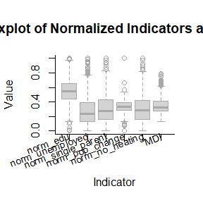

```r
eval(mdi$mdi_detailed$boxplot)
```

Analogously, to reproduce the histogram run

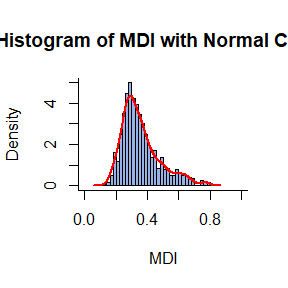

```r
eval(mdi$mdi_detailed$histogram)
```

# Inside pipes

## Pipe |>

*healthiar* can be used inside the *native* pipes `|>`. See the example below.

```r
exdat_noise |>
  (\(df) {
    healthiar::attribute_health(
      approach_risk = df$risk_estimate_type,
      exp_central = df$exposure_mean,
      pop_exp = df$exposed,
      erf_eq_central = df$erf
      )$health_main$impact_rounded
    })()
```

Shorter, making use of the base R function `with()`.

```r
exdat_noise |>
      (\(df) {
        with(df, healthiar::attribute_health(
         approach_risk = risk_estimate_type,
         exp_central = exposure_mean,
         pop_exp = exposed,
         erf_eq_central = erf
         ))$health_main$impact_rounded
        })()
```

```
#> [1] 348464
```

## Pipe %>%

*healthiar* can also be used inside *magrittr* pipes `%>%` as follows.

```r
exdat_noise %>%
  {
    healthiar::attribute_health(
      approach_risk = .$risk_estimate_type,
      exp_central = .$exposure_mean,
      pop_exp = .$exposed,
      erf_eq_central = .$erf
    )$health_main$impact_rounded
  }
```

# Export and visualize

Exporting and visualizing results is out of scope of *healthiar*. To export and visualize, you can make use of existing functions in other packages beyond *healthiar* as indicated below.

## Export results

Export as `.csv` file

```r
write.csv(x = results_pm_copd$health_main, file = "exported_results/results_pm_copd.csv")
```

Save as `.Rdata` file

```r
save(results_pm_copd, file = "exported_results/results_pm_copd.Rdata")
```

Export to Excel (as `.xlsx` file)

```r
openxlsx::write.xlsx(x = results_pm_copd$health_main, file = "exported_results/results_pm_copd.xlsx")
```

## Visualize results

Visualization is out of scope of *healthiar*. You can visualize in:

- R using base programming or packages such as `ggplot2` (Wickham 2016),
- Excel (export results first) or
- Other tools.

# Python package

Using `healthiar` in Python is possible with the dedicated wrapper. The wrapper consists of a Python program that allows you to use the `healthiar` R package as if it were a Python package. In technical terms, the Python package works by running R embedded in a Python process.

The Python wrapper for `healthiar` is an implementation of the [`rpy2` interface](https://rpy2.github.io/).

## Requirements

To use the Python package, you need R, with the `healthiar` package installed.

## Installation

1. Install the `healthiar` Python package with `pip`:

   ```python
   pip install healthiar
   ```

2. Add the path of your R installation as environment variable. In Python, you can do this as follows:

   ```python
   import os

   os.environ['R_HOME'] = "/path/to/R/R-4.6.0"
   # or
   os.environ["PATH"] = "/path/to/R/R-4.6.0/bin/x64"
   ```

## Modules

### Conversion

The `conversion` module contains the functions for converting input and output data, needed for a correct functioning of the wrapper:

- `py_to_r()`: To convert Python input data to the `rpy2` format;
- `r_to_py()`: To convert the `rpy2` output back to Python.

In some cases (e.g., floats and strings) the conversion from Python to `rpy2` object happens automatically. In other cases (e.g., tuples and lists) the conversion needs to be made explicit through a call to `py_to_r()`. The table below gives the R object class corresponding to each relevant Python class, and indicates when to use the conversion function.

| Python type | R class | Conversion |
| --- | --- | --- |
| `int` | `integer` | *automatic* |
| `float` | `double` | *automatic* |
| `str` | `character` | *automatic* |
| `tuple`, `list` | `vector` | `py_to_r()` |
| `pandas.DataFrame`, `pandas.Series`, `numpy.ndarray` | `data.frame` | `py_to_r()` |
| `function` | `function` | *use a decorator (see below)* |

### Wrapper

The `healthiar` module contains the wrapper itself, allowing you to call any function available in the R package. To illustrate a typical workflow, let’s replicate the above example of a call to `attribute_health()` for multiple geographic units:

```python
from healthiar.healthiar import healthiar
from healthiar.conversion import py_to_r, r_to_py

results_iteration = healthiar.attribute_health(
    # Names of Swiss cantons
    geo_id_micro = py_to_r(["Zurich", "Basel", "Geneva", "Ticino", "Jura"]),
    # Names of languages spoken in the selected Swiss cantons
    geo_id_macro = py_to_r(["German","German","French","Italian","French"]),
    rr_central = 1.369,
    rr_increment = 10,
    cutoff_central = 5,
    erf_shape = "log_linear",
    exp_central = py_to_r([11, 11, 10, 8, 7]),
    bhd_central = py_to_r([4000, 2500, 3000, 1500, 500])
)
```

The output is an `rpy2` object. The result in this format can be passed directly to another `healthiar` function, such as `compare()`. To convert the result to a regular Python object, pass it to the `r_to_py()` function:

```python
py_results_iteration = r_to_py(results_iteration)
py_results_iteration["health_main"][["geo_id_macro", "impact_rounded", "erf_ci", "exp_ci", "bhd_ci"]].head()
```

| geo_id_macro | impact_rounded | erf_ci | exp_ci | bhd_ci |
| --- | --- | --- | --- | --- |
| German | 1116.0 | central | central | central |
| French | 466.0 | central | central | central |
| Italian | 135.0 | central | central | central |

To pass a Python function as input to a function from `healthiar`, you need to wrap the `rpy2` function `rternalize()` around it using a decorator. Let’s take the `CubicSpline()` function from `scipy` as an example:

```python
import rpy2.rinterface as ri
from scipy.interpolate import CubicSpline

## define ERF with decorator ('@')
@ri.rternalize
def erf_fun(x):
    cs = CubicSpline(
      x = [0, 5, 10, 15, 20, 25, 30, 50, 70, 90, 110],
      y = [1.00, 1.04, 1.08, 1.12, 1.16, 1.20, 1.23, 1.35, 1.45, 1.53, 1.60]
    )
    return float(cs(x)[0])

## pass ERF to attribute_health()
results_pm_copd_mr_brt = healthiar.attribute_health(
  exp_central = 8.85,
  bhd_central = 30747,
  cutoff_central = 0,
  erf_eq_central = erf_fun
)
```

Note: The use of a decorator is only required when passing Python functions as `erf_eq_central`. Passing equations in the form of a string requires no conversion.

### Spatial data

Conversion of spatial data formats from Python (e.g., `geopandas`, `xarray`) to `rpy2` format is not possible. However, the module `spatial` contains functions to read geographic vector or raster data in way that is compatible with the `healthiar` function `prepare_exposure()`:

```python
from healthiar.spatial import read_raster, read_vector
from importlib.resources import files # to access package data files
import pathlib # to convert Windows path to POSIX path, if running Windows

path = files("healthiar.data")
exdat_pwm_1 = read_raster(path.joinpath("pm25.tif").as_posix())
exdat_pwm_2 = read_vector(path.joinpath("municipalities_brussels.gpkg").as_posix(), quiet = True)

population = [27335, 131426, 86534, 25425, 59840, 42638, 125734, 35369, 203105, 50060, 44735, 57993, 89204, 54077, 22901, 99096, 25630, 49704, 25441]

geo_id_macro = ["North", "North", "South", "South", "East", "East", "West", "East", "Center", "East", "North", "South", "South", "North", "West", "West", "West", "South", "West"]

pwm = healthiar.prepare_exposure(
  poll_grid = exdat_pwm_1, # Formal class SpatRaster,
  geo_units = exdat_pwm_2, # sf of the geographic sub-units
  population = py_to_r(population), # population per geographic sub-unit
  geo_id_macro = py_to_r(geo_id_macro)
)
```

## Documentation

To access the documentation of a `healthiar` function, use the default `?` method from R:

```python
?healthiar.attribute_health
```

# Abbreviations

BHD/bhd = baseline health data

CI = confidence interval

CBA/cba = cost-benefit analysis

exp = exposure

ERF = exposure-response function

RR/rr = relative risk

WHO = World Health Organization

YLL/yll = years of life lost

# References

Ahmad, Omar B, Cynthia Boschi Pinto, Alan D Lopez, Christopher JL Murray, Rafael Lozano, and Mie Inoue. 2001. *Age Standardization of Rates: A New WHO Standard*. GPE Discussion Paper Series: No. 31. World Health Organization.

Askari, Maryam, and Seyedeh Mahdieh Namayandeh. 2020. “The Difference Between the Population Attributable Risk (PAR) and the Potentioal Impact Fraction (PIF).” *Iranian Journal of Public Health* 49 (10): 2018–19. https://doi.org/10.18502/ijph.v49i10.4713.

Attema, Arthur E., Werner B. F. Brouwer, and Karl Claxton. 2018. “Discounting in Economic Evaluations.” *PharmacoEconomics* 36 (7): 745–58. https://doi.org/10.1007/s40273-018-0672-z.

Boardman, Anthony E., David H. Greenberg, Aidan R. Vining, and David L. Weimer. 2018. *Cost-Benefit Analysis: Concepts and Practice*. 5th ed. Cambridge University Press.

Bobinac, N., J. van Exel, F. F. H. Rutten, and W. B. F. Brouwer. 2010. “Willingness to Pay for a Quality-Adjusted Life-Year: The Individual Perspective.” *Value in Health* 13 (8): 1046–55. https://doi.org/10.1111/j.1524-4733.2010.00783.x.

Brealey, Richard A., Stewart C. Myers, Franklin Allen, Simon Benninga, and Julian Read. 2023. *Principles of Corporate Finance*. 14th ed. McGraw-Hill Education.

Chiang, Chin Long. 1984. *The Life Table and Its Applications*. Robert E. Krieger Publishing Company.

Cronbach, Lee J. 1951. “Coefficient Alpha and the Internal Structure of Tests.” *Psychometrika* 16 (3): 297–334. https://doi.org/10.1007/BF02310555.

Devleesschauwer, Brecht, Paul Torgerson, Johannes Charlier, et al. 2022. *Prevalence: Tools for Prevalence Assessment Studies.* https://cran.r-project.org/package=prevalence.

Engelmann, Nicole, Núria Blanes Guàrdia, Jaume Fons-Esteve, Danielle Vienneau, Eulàlia Peris, and Martin Röösli. 2025. *Environmental Noise Health Risk Assessment: Methodology for Assessing Health Risks Using Data Reported Under the Environmental Noise Directive*. ETC HE Report 2023/11. European Topic Centre on Human Health; the Environment (ETC HE). https://www.eionet.europa.eu/etcs/etc-he/products/etc-he-products/etc-he-reports/etc-he-report-2023-11-environmental-noise-health-risk-assessment-methodology-for-assessing-health-risks-using-data-reported-under-the-environmental-noise-directive.

Frederick, Shane, George Loewenstein, and Ted O’Donoghue. 2002. “Time Discounting and Time Preference: A Critical Review.” *Journal of Economic Literature* 40 (2): 351–401. https://doi.org/10.1257/002205102320161311.

GBD 2019 Demographics Collaborators. 2020. “Global Age-Sex-Specific Fertility, Mortality, Healthy Life Expectancy (HALE), and Population Estimates in 204 Countries and Territories, 1950-2019: A Comprehensive Demographic Analysis for the Global Burden of Disease Study 2019.” *The Lancet* 396 (10258): 1160–203. https://doi.org/10.1016/S0140-6736(20)30977-6.

GBD 2019 Risk Factors Collaborators. 2020. “Global Burden of 87 Risk Factors in 204 Countries and Territories, 1990–2019.” *The Lancet*, ahead of print. https://doi.org/10.1016/S0140-6736(20)30752-2.

Hammitt, James K. 2007. “Valuing Changes in Mortality Risk: Lives Saved Versus Life Years Saved.” *Review of Environmental Economics and Policy* 1 (2): 228–40. https://doi.org/10.1093/reep/rem015.

Harvey, Charles M. 1986. “Value Functions for Infinite-Period Planning.” *Management Science* 32 (9): 1123–39. https://doi.org/10.1287/mnsc.32.9.1123.

HM Treasury. 2022. *The Green Book: Central Government Guidance on Appraisal and Evaluation*. HM Treasury. https://www.gov.uk/government/publications/the-green-book-appraisal-and-evaluation-in-central-government.

Jerrett, Michael, Richard T Burnett, Bernardo S Beckerman, et al. 2013. “Spatial Analysis of Air Pollution and Mortality in California.” *American Journal of Respiratory and Critical Care Medicine* 188 (5): 593–99. https://doi.org/10.1164/rccm.201303-0609OC.

Kim, Young-Eun, Yoon-Sun Jung, Minsu Ock, and Seok-Jun Yoon. 2022. “DALY Estimation Approaches: Understanding and Using the Incidence-Based Approach and the Prevalence-Based Approach.” *J. Prev. Med. Public Health* 55 (1): 10–18. https://doi.org/10.3961/jpmph.21.597.

Lehtomäki, Heli, Gunn Marit Aasvang, Gerhard Sulo, et al. 2025. “Burden of Disease Attributable to PM2.5 at Low Exposure Levels: Impact of Methodological Choices.” *Environmental Health* 25 (1): 4. https://doi.org/10.1186/s12940-025-01250-y.

Lipman, Stefan A., and Arthur E. Attema. 2024. “A Systematic Review of Unique Methods for Measuring Discount Rates.” *Journal of Risk and Uncertainty* 69 (2): 145–89. https://doi.org/10.1007/s11166-024-09439-1.

Mazur, James E. 1987. “An Adjusting Procedure for Studying Delayed Reinforcement.” In *Quantitative Analyses of Behavior: Volume v. The Effect of Delay and of Intervening Events on Reinforcement Value*, edited by Michael L. Commons, James E. Mazur, John A. Nevin, and Howard Rachlin. Lawrence Erlbaum Associates.

Miller, B G, and J F Hurley. 2003. “Life Table Methods for Quantitative Impact Assessments in Chronic Mortality.” *Journal of Epidemiology and Community Health* 57 (3): 200–206. https://doi.org/10.1136/jech.57.3.200.

Miller, Brian G. 2010. *Report on Estimation of Mortality Impacts of Particulate Air Pollution in London*. Institute of Occupational Medicine (IOM). https://cleanair.london/app/uploads/CAL-098-Mayors-health-study-report-June-2010-1.pdf.

Mogin, Gaëlle, Vanessa Gorasso, Jane Idavain, et al. 2025. “A Scoping Review of Multiple Deprivation Indices in Europe.” *European Journal of Public Health* 35 (6): 1122–28. https://doi.org/10.1093/eurpub/ckaf190.

Murray, Christopher J L, Majid Ezzati, Alan D Lopez, Anthony Rodgers, and Stephen Vander Hoorn. 2003. “Comparative Quantification of Health Risks Conceptual Framework and Methodological Issues.” *Popul. Health Metr.* 1 (1): 1.

Murray, Christopher JL, Majid Ezzati, Alan D Lopez, Anthony Rodgers, and Stephen Vander Hoorn. 2003. “Comparative Risk Assessment: Conceptual Framework and Design.” *Epidemiology* 14 (4): 447–58. https://doi.org/10.1186/1478-7954-1-1.

OECD. 2025. *Mortality Risk Valuation in Policy Assessment: A Global Meta-Analysis of Value of Statistical Life Studies*. OECD Publishing. https://doi.org/10.1787/76ca89a2-en.

Otavova, Martina, Christel Faes, Catherine Bouland, et al. 2022. “Inequalities in Mortality Associated with Housing Conditions in Belgium Between 1991 and 2020.” *BMC Public Health* 22 (1): 2397. https://doi.org/10.1186/s12889-022-14819-w.

Pozzer, A., S. C. Anenberg, S. Dey, A. Haines, J. Lelieveld, and S. Chowdhury. 2023. “Mortality Attributable to Ambient Air Pollution: A Review of Global Estimates.” *GeoHealth* 7 (1): e2022GH000711. https://doi.org/https://doi.org/10.1029/2022GH000711.

Preston, Samuel H., Patrick Heuveline, and Michel Guillot. 2001. *Demography: Measuring and Modeling Population Processes*. Blackwell Publishers.

Renard, Françoise, Brecht Devleesschauwer, Niko Speybroeck, and Patrick Deboosere. 2019. “Monitoring Health Inequalities When the Socio-Economic Composition Changes: Are the Slope and Relative Indices of Inequality Appropriate? Results of a Simulation Study.” *BMC Public Health* 19 (1): 662. https://doi.org/10.1186/s12889-019-6980-1.

Robert, Christian P, and George Casella. 2004. *Monte Carlo Statistical Methods*. Springer Texts in Statistics. Springer Science; Business Media. https://doi.org/10.1007/978-1-4757-4145-2.

Rubinstein, Reuven Y., and Dirk P. Kroese. 2016. *Simulation and the Monte Carlo Method*. John Wiley; Sons. https://doi.org/10.1002/9781118631980.

Samuelson, Paul A. 1937. “A Note on Measurement of Utility.” *The Review of Economic Studies* 4 (2): 155–61. https://doi.org/10.2307/2967612.

Soares, J., A. González Ortiz, A. Gsella, J. Horálek, D. Plass, and S. Kienzler. 2022. *Health Risk Assessment of Air Pollution and the Impact of the New WHO Guidelines (Eionet Report – ETC HE 2022/10)*. Eionet Report -- ETC HE 2022/10. European Topic Centre on Human Health; the Environment. https://doi.org/10.5281/zenodo.7405988.

Steenland, Kyle, and Ben Armstrong. 2006. “An Overview of Methods for Calculating the Burden of Disease Due to Specific Risk Factors.” *Epidemiology* 17 (5): 512–19. https://doi.org/10.1097/01.ede.0000229155.05644.43.

Strak, Maciek, Danny Houthuijs, and Brigit Staatsen. 2024. *D1.2 Report on the Methodology for Assessing the Burden of Correlated Exposures*. EU Project BEST-COST.

VanderWeele, Tyler J. 2019. “Optimal Approximate Conversions of Odds Ratios and Hazard Ratios to Risk Ratios.” *Biometrics* 76 (3): 746–52. https://doi.org/10.1111/biom.13197.

WHO. 2003. *Introduction and Methods: Assessing the Environmental Burden of Disease at National and Local Levels*. World Health Organization. https://www.who.int/publications/i/item/9241546204.

WHO. 2011. *Burden of Disease from Environmental Noise: Quantification of Healthy Life Years Lost in Europe*. World Health Organization. https://www.who.int/publications/i/item/burden-of-disease-from-environmental-noise-quantification-of-healthy-life-years-lost-in-europe.

WHO. 2020. *Health Impact Assessment of Air Pollution: AirQ+ Life Table Manual*. World Health Organization - Regional Office for Europe. https://www.who.int/europe/publications/i/item/WHO-EURO-2020-1559-41310-56212.

WHO. 2025. *Health Risks of Air Pollution in Europe: HRAPIE-2 Project. Updated Guidance on Concentration-Response Functions for Health Risk Assessment of Air Pollution in the WHO European Region*. World Health Organization - Regional Office for Europe. https://www.who.int/europe/publications/i/item/9789289062633.

WHO Regional Office for Europe. 2014. *WHO Expert Meeting: Methods and Tools for Assessing the Health Risks of Air Pollution at Local, National and International Level. Meeting Report; 12-13 May 2014; Bonn, Germany*. WHO Regional Office for Europe. https://iris.who.int/handle/10665/142940.

Wickham, Hadley. 2014. “Tidy Data.” *Journal of Statistical Software* 59 (10): 1–23. https://doi.org/10.18637/jss.v059.i10.

Wickham, Hadley. 2016. *Ggplot2: Elegant Graphics for Data Analysis*. Springer-Verlag New York. https://ggplot2.tidyverse.org.